# Empirical Results Replication

Youpeng Zhang

July 31, 2018

Clean space and set wd

```r
# clean space and set wd
ls()
rm(list = ls())
setwd("/Users/youpengzhang/Desktop/2018_CGS/referee_report/empirics/STARdatapost")
```

Loading packages and the data

```r
# Packages
library(tidyverse)
library(psych)
library(skimr)
library(dplyr)
library(plyr)
library(sandwich)
library(plm)
library(lmtest)
library(multiwayvcov)
library(stargazer)
library(AER)
library(haven)
library(broom)
library(plotly)
library(egg)
library(commarobust) #Robust Standard Errors for Stargazer Integration
library(reshape2)
library(quantreg)

dat.STAR <- read_dta("STAR_public_use.dta")
```

**Table 1: Descriptive Statistics**

```r
############ Table 1-Descriptive Statistics ############
treat.var <- c("ssp", "sfp" , "sfsp")
admin.var <- c("numcourses_nov1", "noshow", "compsurv")
back.var <- c("female", "gpa0", "age", "english", "hcom",
              "chooseUTM", "work1", "mom1", "mom2", "dad1",
              "dad2", "lm_rarely", "lm_never", "graddeg", "finish4")

#Administrative variables regression
for (i in 1:length(admin.var)) {
  assign(paste("model.admin", i, sep = ""),
         (lm(as.formula(paste(admin.var[[i]], "~ ssp + sfp + sfsp")), data = dat.STAR)))
}

#Administrative control group mean and standard deviations
dat.STAR %>%
  group_by(control) %>%
  summarise(mean.numcourses_nov1 = mean(numcourses_nov1),
            sd.numcourses_nov1 = sd(numcourses_nov1),
            mean.noshow = mean(noshow),
            mean.compsurv = mean(compsurv))
```

```
## # A tibble: 2 x 5
##   control mean.numcourses_nov1 sd.numcourses_nov1 mean.noshow
##     <dbl>                <dbl>              <dbl>       <dbl>
## 1       0             4.693846           1.313715  0.04769231
## 2       1             4.744533           1.370385  0.05367793
## # ... with 1 more variables: mean.compsurv <dbl>
```

```r
#Background variables regression
dat.noshow <- subset(dat.STAR, noshow == 0)

for (i in 1:length(back.var)) {
  assign(paste("model.back", i, sep = ""),
         (lm(as.formula(paste(back.var[[i]], "~ ssp + sfp + sfsp")), data = dat.noshow)))
}

#Background control group mean and standard deviations
dat.noshow.back <- dat.noshow[, c("control","female", "gpa0", "age", "english", "hcom", "chooseUTM", "work1", "mom1", "mom2", "dad1", "dad2", "lm_rarely", "lm_never", "graddeg", "finish4")]

dat.noshow.back %>%
  na.omit(dat.noshow.back) %>%
  group_by(control) %>%
  summarise_all("mean")
```

```
## # A tibble: 2 x 16
##   control    female     gpa0      age   english      hcom chooseUTM
##     <dbl>     <dbl>    <dbl>    <dbl>     <dbl>     <dbl>     <dbl>
## 1       0 0.5896057 78.82437 18.25269 0.7311828 0.7992832 0.2867384
## 2       1 0.5804598 78.67828 18.28161 0.6988506 0.8103448 0.2425287
## # ... with 9 more variables: work1 <dbl>, mom1 <dbl>, mom2 <dbl>,
## #   dad1 <dbl>, dad2 <dbl>, lm_rarely <dbl>, lm_never <dbl>,
## #   graddeg <dbl>, finish4 <dbl>
```

```r
dat.noshow.back %>%
  na.omit(dat.noshow.back) %>%
  group_by(control) %>%
  summarise(sd.gpa0 = sd(gpa0), sd.age = sd(age))
```

```
## # A tibble: 2 x 3
##   control  sd.gpa0    sd.age
##     <dbl>    <dbl>     <dbl>
## 1       0 4.264178 0.5952701
## 2       1 4.216997 0.5972759
```

```r
#Please note that for simplicity, the some Stargazer codes have been hidden in .HTML file and only shown the regression results. For more details, please check the .R code.

stargazer(model.admin1, model.admin2, model.admin3,
          type = "html",
          omit.stat = c("rsq", "adj.rsq", "ser"),
          dep.var.labels.include = FALSE,
          column.labels = c("Courses enrolled fall 2005", "No Show",               "Completed survey"),
          model.names = FALSE,
          model.numbers = TRUE,
          no.space = TRUE,
          notes = "Standard errors are reported in parentheses. Observations show the number of nonmissing observations.",
          notes.align = "l",
          title="Descriptive Statistics", align=TRUE)
```

**Descriptive Statistics**

|  | *Dependent variable:* |  |  |
| --- | --- | --- | --- |
|  | Courses enrolled fall 2005 | No Show | Completed survey |
|  | (1) | (2) | (3) |
| ssp | -0.053 | 0.002 | -0.018 |
|  | (0.095) | (0.016) | (0.022) |
| sfp | 0.015 | -0.030* | -0.010 |
|  | (0.095) | (0.016) | (0.022) |
| sfsp | -0.158 | 0.020 | -0.051* |
|  | (0.118) | (0.019) | (0.028) |
| Constant | 4.745*** | 0.054*** | 0.898*** |
|  | (0.043) | (0.007) | (0.010) |
| Observations | 1,656 | 1,656 | 1,656 |
| F Statistic (df = 3; 1652) | 0.702 | 1.852 | 1.228 |
| *Note:* | p<0.1; p<0.05; p<0.01 |  |  |
|  | Standard errors are reported in parentheses. Observations show the number of nonmissing observations. |  |  |

```r
stargazer(model.back1, model.back2, model.back3, model.back4, model.back5,
          model.back6, model.back7, model.back8, model.back9, model.back10,
          model.back11, model.back12, model.back13, model.back14, model.back15,
          type = "html",
          omit.stat = c("rsq", "adj.rsq", "ser"),
          dep.var.labels.include = FALSE,
          column.labels = c("female", "gpa0", "age", "english", "hcom",
          "chooseUTM", "work1", "mom1", "mom2", "dad1",
          "dad2", "rarely", "never", "graddeg", "finish4"),
          model.names = FALSE,
          model.numbers = TRUE,
          no.space = TRUE,
          notes = "Standard errors are reported in parentheses. Observations show the number of nonmissing observations.",
          notes.align = "l",
          title="Descriptive Statistics", align=TRUE)
```

**Descriptive Statistics**

|  | *Dependent variable:* |  |  |  |  |  |  |  |  |  |  |  |  |  |  |
| --- | --- | --- | --- | --- | --- | --- | --- | --- | --- | --- | --- | --- | --- | --- | --- |
|  | female | gpa0 | age | english | hcom | chooseUTM | work1 | mom1 | mom2 | dad1 | dad2 | rarely | never | graddeg | finish4 |
|  | (1) | (2) | (3) | (4) | (5) | (6) | (7) | (8) | (9) | (10) | (11) | (12) | (13) | (14) | (15) |
| ssp | -0.006 | 0.170 | -0.054 | 0.017 | -0.040 | 0.024 | 0.031 | 0.015 | 0.053 | 0.025 | 0.021 | 0.031 | -0.019 | 0.052 | -0.008 |
|  | (0.036) | (0.308) | (0.045) | (0.033) | (0.030) | (0.034) | (0.032) | (0.026) | (0.037) | (0.028) | (0.038) | (0.032) | (0.016) | (0.038) | (0.030) |
| sfp | 0.029 | 0.238 | -0.033 | 0.009 | 0.009 | 0.060* | -0.066** | -0.021 | -0.020 | 0.008 | -0.001 | 0.031 | -0.016 | -0.029 | -0.006 |
|  | (0.035) | (0.304) | (0.044) | (0.033) | (0.030) | (0.033) | (0.031) | (0.026) | (0.036) | (0.027) | (0.037) | (0.031) | (0.016) | (0.037) | (0.029) |
| sfsp | -0.005 | -0.018 | 0.026 | 0.049 | -0.004 | 0.047 | 0.037 | -0.045 | -0.052 | -0.017 | -0.024 | 0.107*** | -0.032 | 0.073 | -0.063* |
|  | (0.045) | (0.384) | (0.056) | (0.041) | (0.038) | (0.042) | (0.040) | (0.033) | (0.046) | (0.035) | (0.048) | (0.040) | (0.021) | (0.048) | (0.037) |
| Constant | 0.574*** | 78.657*** | 18.291*** | 0.700*** | 0.811*** | 0.243*** | 0.777*** | 0.868*** | 0.358*** | 0.839*** | 0.451*** | 0.208*** | 0.056*** | 0.556*** | 0.821*** |
|  | (0.016) | (0.137) | (0.020) | (0.015) | (0.013) | (0.015) | (0.014) | (0.012) | (0.016) | (0.012) | (0.017) | (0.014) | (0.007) | (0.017) | (0.013) |
| Observations | 1,571 | 1,571 | 1,571 | 1,571 | 1,431 | 1,430 | 1,431 | 1,431 | 1,431 | 1,431 | 1,431 | 1,431 | 1,431 | 1,431 | 1,431 |
| F Statistic | 0.272 (df = 3; 1567) | 0.276 (df = 3; 1567) | 0.752 (df = 3; 1567) | 0.495 (df = 3; 1567) | 0.685 (df = 3; 1427) | 1.362 (df = 3; 1426) | 2.541* (df = 3; 1427) | 1.040 (df = 3; 1427) | 1.487 (df = 3; 1427) | 0.416 (df = 3; 1427) | 0.216 (df = 3; 1427) | 2.534* (df = 3; 1427) | 1.206 (df = 3; 1427) | 1.752 (df = 3; 1427) | 0.942 (df = 3; 1427) |
| *Note:* | p<0.1; p<0.05; p<0.01 |  |  |  |  |  |  |  |  |  |  |  |  |  |  |
|  | Standard errors are reported in parentheses. Observations show the number of nonmissing observations. |  |  |  |  |  |  |  |  |  |  |  |  |  |  |

**Table 2: Selection Effects**

```r
############ Table 2-Selection Effects ############
rm(list = ls())
dat.STAR <- read_dta("STAR_public_use.dta")

#Dummy for has fall grades
dat.STAR$hasfall <- ifelse(is.na(dat.STAR$grade_20059_fall), 0, 1)

#Converting multiple variables to factor
cols <- c("sex", "mtongue", "hsgroup", "numcourses_nov1", "lastmin", "mom_edn", "dad_edn")
dat.STAR[,cols] <- lapply(dat.STAR[,cols] , factor)

#Creating three subsets
dat.noshow <- subset(dat.STAR, noshow == 0)
dat.male <- subset(dat.noshow, sex == "M")
dat.female<- subset(dat.noshow, sex == "F")
list_data <- list("dat.noshow" = dat.noshow, "dat.male" = dat.male,
                  "dat.female" = dat.female)

#Relevant set of controls
dep.var <-  c("totcredits_year1", "mathsci", "hasfall")
basic.var <- c("ssp", "sfp", "sfsp", "sex", "mtongue", "hsgroup", "numcourses_nov1")
cont.var <- c("ssp", "sfp", "sfsp", "sex", "mtongue", "hsgroup", "numcourses_nov1",
              "lastmin", "mom_edn", "dad_edn")

#Control group mean and standard deviations
dat.noshow %>%
  group_by(control) %>%
  summarise(mean.totcredits_year1 = mean(totcredits_year1),
            sd.totcredits_year1 = sd(totcredits_year1),
            mean.mathsci = mean(mathsci),
            sd.mathsci = sd(mathsci),
            mean.hasfall = mean(hasfall),
            sd.hasfall = sd(hasfall))
```

```
## # A tibble: 2 x 7
##   control mean.totcredits_year1 sd.totcredits_year1 mean.mathsci
##     <dbl>                 <dbl>               <dbl>        <dbl>
## 1       0              4.046850           0.8892029     1.119548
## 2       1              4.048845           0.8927673     1.094538
## # ... with 3 more variables: sd.mathsci <dbl>, mean.hasfall <dbl>,
## #   sd.hasfall <dbl>
```

```r
dat.male %>%
  group_by(control) %>%
  summarise(mean.totcredits_year1 = mean(totcredits_year1),
            sd.totcredits_year1 = sd(totcredits_year1),
            mean.mathsci = mean(mathsci),
            sd.mathsci = sd(mathsci),
            mean.hasfall = mean(hasfall),
            sd.hasfall = sd(hasfall))
```

```
## # A tibble: 2 x 7
##   control mean.totcredits_year1 sd.totcredits_year1 mean.mathsci
##     <dbl>                 <dbl>               <dbl>        <dbl>
## 1       0              3.907336           0.9488387     1.239382
## 2       1              3.964286           0.9437673     1.158867
## # ... with 3 more variables: sd.mathsci <dbl>, mean.hasfall <dbl>,
## #   sd.hasfall <dbl>
```

```r
dat.female %>%
  group_by(control) %>%
  summarise(mean.totcredits_year1 = mean(totcredits_year1),
            sd.totcredits_year1 = sd(totcredits_year1),
            mean.mathsci = mean(mathsci),
            sd.mathsci = sd(mathsci),
            mean.hasfall = mean(hasfall),
            sd.hasfall = sd(hasfall))
```

```
## # A tibble: 2 x 7
##   control mean.totcredits_year1 sd.totcredits_year1 mean.mathsci
##     <dbl>                 <dbl>               <dbl>        <dbl>
## 1       0              4.147222           0.8306410     1.033333
## 2       1              4.111722           0.8482956     1.046703
## # ... with 3 more variables: sd.mathsci <dbl>, mean.hasfall <dbl>,
## #   sd.hasfall <dbl>
```

```r
#Panel A. All
for (i in 1:length(dep.var)) {
  assign(paste("model.noshow.basic", i, sep = ""),
         (lm(as.formula(paste(dep.var[[i]], "~ ssp + sfp + sfsp + sex + mtongue + hsgroup + numcourses_nov1")), data = dat.noshow)))
}

for (i in 1:length(dep.var)) {
  assign(paste("model.noshow.cont", i, sep = ""),
         (lm(as.formula(paste(dep.var[[i]], "~ ssp + sfp + sfsp + sex + mtongue + hsgroup + numcourses_nov1 +
                              lastmin + mom_edn +dad_edn")), data = dat.noshow)))
}
```

```r
#Custom the table
custom_table <- function(dataset_labels, ..., cat_output=TRUE, out_file=NULL) {
  tbl <- capture.output(stargazer::stargazer(...))
  pattern1 <- 'Dependent variable:'
  pattern2 <- '(?<= \\& ).+(?= \\\\)'
  first_row_index <- which(grepl(pattern=pattern1, x=tbl))
  first_row <- tbl[first_row_index]
  colspan <- as.numeric(gsub(pattern='[^0-9]+', replacement='', first_row))
  colspan <- colspan / length(dataset_labels)
  new_first_row <- sub('[0-9]+', colspan, first_row)
  replacement <- rep(stringr::str_extract(new_first_row, pattern2), 2)
  replacement <- stringr::str_replace(replacement, pattern1, dataset_labels)
  replacement <- paste(replacement, collapse=' & ')
  new_first_row <- stringr::str_replace(new_first_row, pattern2, replacement)
  new_first_row <- stringr::str_replace_all(new_first_row, 'multi', '\\\\multi')
  new_first_row <- stringr::str_replace_all(new_first_row, 'text', '\\\\text')
  tbl[first_row_index] <- new_first_row
  if ( cat_output ) {
    cat(tbl, sep='\n')
  }
  if ( !is.null(out_file) ) {
    cat(tbl, sep='\n', file=out_file)
  }
}
```

**Selection Effects: Panel A. All**

|  | *Dependent variable:* |  |  |  |  |  |
| --- | --- | --- | --- | --- | --- | --- |
|  | totcredits |  | mathsci |  | hasfall |  |
|  | (1) | (2) | (3) | (4) | (5) | (6) |
| Offered SSP | 0.076 | 0.049 | 0.073 | 0.081 | 0.004 | 0.0001 |
|  | (0.056) | (0.060) | (0.085) | (0.091) | (0.022) | (0.023) |
| Offered SFP | 0.020 | 0.037 | 0.096 | 0.115 | 0.007 | -0.004 |
|  | (0.056) | (0.054) | (0.080) | (0.086) | (0.022) | (0.023) |
| SFSP | -0.070 | -0.086 | -0.148 | -0.139 | -0.039 | -0.041 |
|  | (0.074) | (0.081) | (0.094) | (0.104) | (0.032) | (0.034) |
| Constant | 1.857*** | 1.917*** | -0.064 | -0.404 | 0.722*** | 0.893*** |
|  | (0.292) | (0.249) | (0.210) | (0.313) | (0.159) | (0.168) |
| Observations | 1,571 | 1,431 | 1,571 | 1,431 | 1,571 | 1,431 |
| *Note:* | p<0.1; p<0.05; p<0.01 |  |  |  |  |  |
|  | The table reports regression estimates of treatment effects on the dependent variables indicated at left. Robust standard errors are reported in parentheses. The sample is limited to students register… |  |  |  |  |  |

```r
#Panel B. Men
for (i in 1:length(dep.var)) {
  assign(paste("model.male.basic", i, sep = ""),
         (lm(as.formula(paste(dep.var[[i]], "~ ssp + sfp + sfsp + mtongue + hsgroup + numcourses_nov1")), data = dat.male)))
}

for (i in 1:length(dep.var)) {
  assign(paste("model.male.cont", i, sep = ""),
         (lm(as.formula(paste(dep.var[[i]], "~ ssp + sfp + sfsp + mtongue + hsgroup + numcourses_nov1 +
                              lastmin + mom_edn +dad_edn")), data = dat.male)))
}
```

**Selection Effects: Panel B. Men**

|  | *Dependent variable:* |  |  |  |  |  |
| --- | --- | --- | --- | --- | --- | --- |
|  | totcredits |  | mathsci |  | hasfall |  |
|  | (1) | (2) | (3) | (4) | (5) | (6) |
| Offered SSP | 0.080 | 0.032 | 0.012 | 0.020 | 0.016 | 0.016 |
|  | (0.088) | (0.101) | (0.126) | (0.139) | (0.029) | (0.031) |
| Offered SFP | -0.123 | -0.063 | 0.276** | 0.344** | -0.035 | -0.051 |
|  | (0.098) | (0.089) | (0.138) | (0.149) | (0.036) | (0.039) |
| SFSP | -0.133 | -0.115 | -0.117 | -0.048 | -0.068 | -0.089 |
|  | (0.117) | (0.137) | (0.160) | (0.184) | (0.048) | (0.057) |
| Constant | 1.596*** | 1.549*** | 0.072 | -0.472 | 0.728*** | 0.908*** |
|  | (0.279) | (0.264) | (0.242) | (0.459) | (0.179) | (0.203) |
| Observations | 665 | 594 | 665 | 594 | 665 | 594 |
| *Note:* | p<0.1; p<0.05; p<0.01 |  |  |  |  |  |
|  | The table reports regression estimates of treatment effects on the dependent variables indicated at left. Robust standard errors are reported in parentheses. The sample is limited to students register… |  |  |  |  |  |

```r
#Panel C. Women
for (i in 1:length(dep.var)) {
  assign(paste("model.female.basic", i, sep = ""),
         (lm(as.formula(paste(dep.var[[i]], "~ ssp + sfp + sfsp + mtongue + hsgroup + numcourses_nov1")), data = dat.female)))
}

for (i in 1:length(dep.var)) {
  assign(paste("model.female.cont", i, sep = ""),
         (lm(as.formula(paste(dep.var[[i]], "~ ssp + sfp + sfsp + mtongue + hsgroup + numcourses_nov1 + lastmin + mom_edn +dad_edn")), data = dat.female)))
}
```

**Selection Effects: Panel C. Women**

|  | *Dependent variable:* |  |  |  |  |  |
| --- | --- | --- | --- | --- | --- | --- |
|  | totcredits |  | mathsci |  | hasfall |  |
|  | (1) | (2) | (3) | (4) | (5) | (6) |
| Offered SSP | 0.072 | 0.058 | 0.118 | 0.132 | -0.003 | -0.013 |
|  | (0.072) | (0.077) | (0.116) | (0.123) | (0.031) | (0.032) |
| Offered SFP | 0.111* | 0.093 | -0.015 | -0.004 | 0.034 | 0.021 |
|  | (0.066) | (0.071) | (0.096) | (0.104) | (0.027) | (0.029) |
| SFSP | -0.046 | -0.108 | -0.179 | -0.153 | -0.015 | -0.011 |
|  | (0.097) | (0.103) | (0.116) | (0.127) | (0.042) | (0.044) |
| Constant | 3.046*** | 2.978*** | 0.179 | -0.192 | 1.015*** | 1.126*** |
|  | (0.097) | (0.203) | (0.116) | (0.251) | (0.042) | (0.079) |
| Observations | 906 | 837 | 906 | 837 | 906 | 837 |
| *Note:* | p<0.1; p<0.05; p<0.01 |  |  |  |  |  |
|  | The table reports regression estimates of treatment effects on the dependent variables indicated at left. Robust standard errors are reported in parentheses. The sample is limited to students register… |  |  |  |  |  |

**Table 3: Program Sign-up and Use of Services**

```r
############ Table 3-Program Sign-up and Use of Services ############
rm(list = ls())
dat.STAR <- read_dta("STAR_public_use.dta")

#Converting multiple variables to factor
cols <- c("mtongue", "hsgroup", "numcourses_nov1", "lastmin", "mom_edn", "dad_edn")
dat.STAR[,cols] <- lapply(dat.STAR[,cols] , factor)

#Creating three subsets
dat.noshow <- subset(dat.STAR, noshow == 0)
dat.male <- subset(dat.noshow, sex == "M")
dat.female<- subset(dat.noshow, sex == "F")
dat.list <- list("dat.noshow" = dat.noshow, "dat.male" = dat.male,
                  "dat.female" = dat.female)

#Relevant set of dependent variables
dep.var <-  c("used_ssp", "used_adv", "used_fsg")

#Panel A. All
model.noshow.signup1 <- lm(signup ~ ssp + sfp + sfsp + sex + mtongue + hsgroup + numcourses_nov1, data = dat.noshow)
model.noshow.signup2 <- lm(signup ~ ssp + sfp + sfsp + sex + mtongue + hsgroup + numcourses_nov1 +
                           lastmin + mom_edn + dad_edn, data = dat.noshow)

for (i in 1:length(dep.var)) {
  assign(paste("model.noshow.basic", i, sep = ""),
         (lm(as.formula(paste(dep.var[[i]], "~ ssp + sfsp + sex + mtongue + hsgroup + numcourses_nov1")), data = dat.noshow)))
}

for (i in 1:length(dep.var)) {
  assign(paste("model.noshow.cont", i, sep = ""),
         (lm(as.formula(paste(dep.var[[i]], "~ ssp + sfsp + sex + mtongue + hsgroup + numcourses_nov1 +
                              lastmin + mom_edn +dad_edn")), data = dat.noshow)))
}
```

**Program Sign-up and Use of Services: Panel A. All**

|  | *Dependent variable:* |  |  |  |  |  |  |  |
| --- | --- | --- | --- | --- | --- | --- | --- | --- |
|  | signup |  | usedssp |  | usedadv |  | usedfsg |  |
|  | (1) | (2) | (3) | (4) | (5) | (6) | (7) | (8) |
| Offered SSP | 0.519*** | 0.549*** | 0.238*** | 0.255*** | 0.205*** | 0.218*** | 0.107*** | 0.118*** |
|  | (0.032) | (0.034) | (0.028) | (0.029) | (0.026) | (0.028) | (0.020) | (0.021) |
| Offered SFP | 0.863*** | 0.867*** |  |  |  |  |  |  |
|  | (0.022) | (0.022) |  |  |  |  |  |  |
| SFSP | 0.762*** | 0.792*** | 0.412*** | 0.431*** | 0.383*** | 0.398*** | 0.131*** | 0.138*** |
|  | (0.036) | (0.036) | (0.041) | (0.044) | (0.041) | (0.043) | (0.029) | (0.031) |
| Observations | 1,571 | 1,431 | 1,571 | 1,431 | 1,571 | 1,431 | 1,571 | 1,431 |
| *Note:* | p<0.1; p<0.05; p<0.01 |  |  |  |  |  |  |  |
|  | The table reports regression estimates of treatment effects on the dependent variables indicated in column headings. Robust standard errors are reported in parentheses. The sample is limited to studen… |  |  |  |  |  |  |  |

```r
#Panel B. Men
model.male.signup1 <- lm(signup ~ ssp + sfp + sfsp + mtongue + hsgroup + numcourses_nov1, data = dat.male)
model.male.signup2 <- lm(signup ~ ssp + sfp + sfsp + mtongue + hsgroup + numcourses_nov1 +
                         lastmin + mom_edn + dad_edn, data = dat.male)

for (i in 1:length(dep.var)) {
  assign(paste("model.male.basic", i, sep = ""),
         (lm(as.formula(paste(dep.var[[i]], "~ ssp + sfsp + mtongue + hsgroup + numcourses_nov1")), data = dat.male)))
}

for (i in 1:length(dep.var)) {
  assign(paste("model.male.cont", i, sep = ""),
         (lm(as.formula(paste(dep.var[[i]], "~ ssp + sfsp + mtongue + hsgroup + numcourses_nov1 +
                              lastmin + mom_edn +dad_edn")), data = dat.male)))
}
```

**Program Sign-up and Use of Services: Panel B. Men**

|  | *Dependent variable:* |  |  |  |  |  |  |  |
| --- | --- | --- | --- | --- | --- | --- | --- | --- |
|  | signup |  | usedssp |  | usedadv |  | usedfsg |  |
|  | (1) | (2) | (3) | (4) | (5) | (6) | (7) | (8) |
| Offered SSP | 0.447*** | 0.464*** | 0.193*** | 0.204*** | 0.145*** | 0.148*** | 0.096*** | 0.106*** |
|  | (0.049) | (0.052) | (0.039) | (0.042) | (0.035) | (0.037) | (0.029) | (0.031) |
| Offered SFP | 0.792*** | 0.806*** |  |  |  |  |  |  |
|  | (0.040) | (0.040) |  |  |  |  |  |  |
| SFSP | 0.705*** | 0.708*** | 0.298*** | 0.289*** | 0.282*** | 0.270*** | 0.115*** | 0.111** |
|  | (0.058) | (0.065) | (0.058) | (0.063) | (0.057) | (0.061) | (0.042) | (0.046) |
| Observations | 665 | 594 | 665 | 594 | 665 | 594 | 665 | 594 |
| *Note:* | p<0.1; p<0.05; p<0.01 |  |  |  |  |  |  |  |
|  | The table reports regression estimates of treatment effects on the dependent variables indicated in column headings. Robust standard errors are reported in parentheses. The sample is limited to studen… |  |  |  |  |  |  |  |

```r
#Panel C. Women
model.female.signup1 <- lm(signup ~ ssp + sfp + sfsp + mtongue + hsgroup + numcourses_nov1, data = dat.female)
model.female.signup2 <- lm(signup ~ ssp + sfp + sfsp + mtongue + hsgroup + numcourses_nov1 +
                           lastmin + mom_edn + dad_edn, data = dat.female)

for (i in 1:length(dep.var)) {
  assign(paste("model.female.basic", i, sep = ""),
         (lm(as.formula(paste(dep.var[[i]], "~ ssp + sfsp + mtongue + hsgroup + numcourses_nov1")), data = dat.female)))
}

for (i in 1:length(dep.var)) {
  assign(paste("model.female.cont", i, sep = ""),
         (lm(as.formula(paste(dep.var[[i]], "~ ssp + sfsp + mtongue + hsgroup + numcourses_nov1 +
                           lastmin + mom_edn + dad_edn")), data = dat.female)))
}
```

**Program Sign-up and Use of Services: Panel C. Women**

|  | *Dependent variable:* |  |  |  |  |  |  |  |
| --- | --- | --- | --- | --- | --- | --- | --- | --- |
|  | signup |  | usedssp |  | usedadv |  | usedfsg |  |
|  | (1) | (2) | (3) | (4) | (5) | (6) | (7) | (8) |
| Offered SSP | 0.571*** | 0.605*** | 0.273*** | 0.288*** | 0.251*** | 0.265*** | 0.113*** | 0.124*** |
|  | (0.043) | (0.044) | (0.038) | (0.040) | (0.037) | (0.040) | (0.027) | (0.029) |
| Offered SFP | 0.912*** | 0.908*** |  |  |  |  |  |  |
|  | (0.024) | (0.026) |  |  |  |  |  |  |
| SFSP | 0.800*** | 0.835*** | 0.506*** | 0.533*** | 0.466*** | 0.490*** | 0.146*** | 0.155*** |
|  | (0.046) | (0.043) | (0.056) | (0.058) | (0.056) | (0.058) | (0.040) | (0.042) |
| Observations | 906 | 837 | 906 | 837 | 906 | 837 | 906 | 837 |
| *Note:* | p<0.1; p<0.05; p<0.01 |  |  |  |  |  |  |  |
|  | The table reports regression estimates of treatment effects on the dependent variables indicated in column headings. Robust standard errors are reported in parentheses. The sample is limited to studen… |  |  |  |  |  |  |  |

```r
############ Table 4-Analysis of Gender-Adviser Interaction ############
#data is not available
```

**Table 5: Treatment Effects on First Year Outcomes in the Sample with Fall Grades**

```r
############ Table 5- Treatment Effects on First Year Outcomes in the Sample with Fall Grades ############
rm(list = ls())
dat.STAR <- read_dta("STAR_public_use.dta")

#Control group mean and standard deviations
dat.STAR.ms <- dat.STAR[ ,c("sex","noshow","control","grade_20059_fall", "GPA_year1")]
dat.noshow.ms <- subset(dat.STAR.ms, noshow == 0)
dat.male.ms <- subset(dat.noshow.ms, sex == "M")
dat.female.ms <- subset(dat.noshow.ms, sex == "F")

dat.noshow.ms %>%
  na.omit(dat.noshow.ms) %>%
  group_by(control) %>%
  summarise(mean.grade_20059_fall = mean(grade_20059_fall),
            sd.grade_20059_fall = sd(grade_20059_fall),
            mean.GPA_year1 = mean(GPA_year1),
            sd.GPA_year1 = sd(GPA_year1))
```

```
## # A tibble: 2 x 5
##   control mean.grade_20059_fall sd.grade_20059_fall mean.GPA_year1
##     <dbl>                 <dbl>               <dbl>          <dbl>
## 1       0              65.50186            11.27924       1.858813
## 2       1              64.12824            11.77817       1.797449
## # ... with 1 more variables: sd.GPA_year1 <dbl>
```

```r
dat.male.ms %>%
  na.omit(dat.male.ms) %>%
  group_by(control) %>%
  summarise(mean.grade_20059_fall = mean(grade_20059_fall),
            sd.grade_20059_fall = sd(grade_20059_fall),
            mean.GPA_year1 = mean(GPA_year1),
            sd.GPA_year1 = sd(GPA_year1))
```

```
## # A tibble: 2 x 5
##   control mean.grade_20059_fall sd.grade_20059_fall mean.GPA_year1
##     <dbl>                 <dbl>               <dbl>          <dbl>
## 1       0              65.56808            11.64924       1.844911
## 2       1              65.73246            11.17780       1.885014
## # ... with 1 more variables: sd.GPA_year1 <dbl>
```

```r
dat.female.ms %>%
  na.omit(dat.female.ms) %>%
  group_by(control) %>%
  summarise(mean.grade_20059_fall = mean(grade_20059_fall),
            sd.grade_20059_fall = sd(grade_20059_fall),
            mean.GPA_year1 = mean(GPA_year1),
            sd.GPA_year1 = sd(GPA_year1))
```

```
## # A tibble: 2 x 5
##   control mean.grade_20059_fall sd.grade_20059_fall mean.GPA_year1
##     <dbl>                 <dbl>               <dbl>          <dbl>
## 1       0              65.45476            11.02707       1.868698
## 2       1              62.90647            12.08503       1.730759
## # ... with 1 more variables: sd.GPA_year1 <dbl>
```

```r
#Only do GPA for FALL grade sample
dat.STAR$GPA_year1[dat.STAR$grade_20059_fall =='.'] = '.'

#Only do FALL grade for GPA sample
dat.STAR$grade_20059_fall[dat.STAR$GPA_year1 =='.'] = '.'

#New dummy for any SFP
dat.STAR$sfpany <- as.integer(dat.STAR$sfp|dat.STAR$sfsp)

#Converting multiple variables to factor
cols <- c("mtongue", "hsgroup", "numcourses_nov1", "lastmin", "mom_edn", "dad_edn")
dat.STAR[,cols] <- lapply(dat.STAR[,cols] , factor)

#Creating three subsets
dat.noshow <- subset(dat.STAR, noshow == 0)
dat.male <- subset(dat.noshow, sex == "M")
dat.female <- subset(dat.noshow, sex == "F")
list_data <- list("dat.noshow" = dat.noshow, "dat.male" = dat.male,
                  "dat.female" = dat.female)

#Relevant set of dependent variables
dep.var <-  c("grade_20059_fall", "GPA_year1")

#Panel A. Fall grade
model.fall.type1 <- lm(grade_20059_fall ~ ssp + sfp + sfsp + sex + mtongue + hsgroup + numcourses_nov1 +
                         lastmin + mom_edn + dad_edn, data = dat.noshow)
for (i in 2:3) {
  assign(paste("model.fall.type", i, sep = ""),
         (lm(grade_20059_fall ~ ssp + sfp + sfsp + mtongue + hsgroup + numcourses_nov1 +
             lastmin + mom_edn + dad_edn, data = list_data[[i]])))
}

model.fall.any1 <- lm(grade_20059_fall ~ ssp + sfpany + sex + mtongue + hsgroup + numcourses_nov1 +
                         lastmin + mom_edn + dad_edn, data = dat.noshow)
for (i in 2:3) {
  assign(paste("model.fall.any", i, sep = ""),
         (lm(grade_20059_fall ~ ssp + sfpany + mtongue + hsgroup + numcourses_nov1 +
               lastmin + mom_edn + dad_edn, data = list_data[[i]])))
}
```

**Treatment Effects on First Year Outcomes in the Sample with Fall Grades: Panel A. Fall grade**

|  | Dependent Variable: Fall grade |  |  |  |  |  |
| --- | --- | --- | --- | --- | --- | --- |
|  | All | Men | Women | All | Men | Women |
|  | (1) | (2) | (3) | (4) | (5) | (6) |
| SSP | 0.231 | -0.019 | 0.618 | 0.225 | -0.015 | 0.620 |
|  | (0.962) | (1.480) | (1.480) | (0.961) | (1.478) | (1.284) |
| SFP | 1.744** | 0.567 | 2.291* |  |  |  |
|  | (0.871) | (1.265) | (1.265) |  |  |  |
| SFSP | 3.112*** | 0.211 | 4.343** |  |  |  |
|  | (1.111) | (1.963) | (1.963) |  |  |  |
| SFP(any) |  |  |  | 2.212*** | 0.443 | 2.977*** |
|  |  |  |  | (0.745) | (1.186) | (0.996) |
| Observations | 1,274 | 539 | 735 | 1,274 | 539 | 735 |
| *Note:* | p<0.1; p<0.05; p<0.01 |  |  |  |  |  |
|  | The table reports regression estimates of treatment effects on full grades as the dependent variable using the full set of controls. Robust standard errors are reported in parentheses. The sample is l… |  |  |  |  |  |

```r
#Panel B. First year GPA
model.year.type1 <- lm(GPA_year1 ~ ssp + sfp + sfsp + sex + mtongue + hsgroup + numcourses_nov1 +
                         lastmin + mom_edn + dad_edn, data = dat.noshow)
for (i in 2:3) {
  assign(paste("model.year.type", i, sep = ""),
         (lm(GPA_year1 ~ ssp + sfp + sfsp + mtongue + hsgroup + numcourses_nov1 +
               lastmin + mom_edn + dad_edn, data = list_data[[i]])))
}

model.year.any1 <- lm(GPA_year1 ~ ssp + sfpany + sex + mtongue + hsgroup + numcourses_nov1 +
                         lastmin + mom_edn + dad_edn, data = dat.noshow)
for (i in 2:3) {
  assign(paste("model.year.any", i, sep = ""),
         (lm(GPA_year1 ~ ssp + sfpany + mtongue + hsgroup + numcourses_nov1 +
               lastmin + mom_edn + dad_edn, data = list_data[[i]])))
}
```

**Treatment Effects on First Year Outcomes in the Sample with Fall Grades: Panel B. First year GPA**

[output not shown]

**Table 6: Treatment Effects on First and Second Year Outcomes**

```r
############ Table 6-Treatment Effects on First and Second Year Outcomes ############
rm(list = ls())
dat.STAR <- read_dta("STAR_public_use.dta")

#Converting multiple variables to factor
cols <- c("mtongue", "hsgroup", "numcourses_nov1", "lastmin", "mom_edn", "dad_edn")
dat.STAR[,cols] <- lapply(dat.STAR[,cols] , factor)

#Creating subset
dat.noshow <- subset(dat.STAR, noshow == 0)

#Control group mean and standard deviations
dat.noshow.ms <- dat.noshow[ ,c("sex", "control","GPA_year1", "GPA_year2", "prob_year1", "prob_year2",
                                "goodstanding_year1", "goodstanding_year2", "credits_earned1","credits_earned2")]
dat.male.ms <- subset(dat.noshow.ms, sex == "M")
dat.female.ms <- subset(dat.noshow.ms, sex == "F")

ddply(dat.noshow.ms, .(control), colwise(mean), na.rm=TRUE)
```

```
##   control sex GPA_year1 GPA_year2 prob_year1 prob_year2 goodstanding_year1
## 1       0  NA  1.793228  2.067933  0.1983607  0.2426230          0.4781906
## 2       1  NA  1.784506  2.028317  0.2228089  0.2523759          0.4537815
##   goodstanding_year2 credits_earned1 credits_earned2
## 1          0.6348950        2.352869        2.453689
## 2          0.6260504        2.353112        2.454641
```

```r
ddply(dat.noshow.ms, .(control), colwise(sd), na.rm=TRUE)
```

```
##   control sex GPA_year1 GPA_year2 prob_year1 prob_year2 goodstanding_year1
## 1       0  NA 0.8862527 0.9328967  0.3990925  0.4290207          0.4999281
## 2       1  NA 0.9166806 0.8918866  0.4163510  0.4346053          0.4981210
##   goodstanding_year2 credits_earned1 credits_earned2
## 1          0.4818490       0.9692374        1.442240
## 2          0.4841048       1.0073559        1.508485
```

```r
ddply(dat.male.ms, .(control), colwise(mean), na.rm=TRUE)
```

```
##   control sex GPA_year1 GPA_year2 prob_year1 prob_year2 goodstanding_year1
## 1       0  NA  1.790763  1.973991  0.1757812  0.2460938          0.4247104
## 2       1  NA  1.850685  2.043949  0.1658416  0.2623762          0.4630542
##   goodstanding_year2 credits_earned1 credits_earned2
## 1          0.6216216        2.255859        2.353516
## 2          0.6256158        2.425309        2.380247
```

```r
ddply(dat.male.ms, .(control), colwise(sd), na.rm=TRUE)
```

```
##   control sex GPA_year1 GPA_year2 prob_year1 prob_year2 goodstanding_year1
## 1       0  NA 0.9097132 1.0018913  0.3813796  0.4315776          0.4952560
## 2       1  NA 0.9095632 0.9211933  0.3723995  0.4404715          0.4992484
##   goodstanding_year2 credits_earned1 credits_earned2
## 1          0.4859216       0.9591994        1.438793
## 2          0.4845606       1.1065490        1.527850
```

```r
ddply(dat.female.ms, .(control), colwise(mean), na.rm=TRUE)
```

```
##   control sex GPA_year1 GPA_year2 prob_year1 prob_year2 goodstanding_year1
## 1       0  NA  1.794972  2.139934  0.2146893  0.2401130          0.5166667
## 2       1  NA  1.736041  2.016709  0.2651934  0.2449355          0.4468864
##   goodstanding_year2 credits_earned1 credits_earned2
## 1          0.6444444        2.423023        2.526130
## 2          0.6263736        2.299263        2.510129
```

```r
ddply(dat.female.ms, .(control), colwise(sd), na.rm=TRUE)
```

```
##   control sex GPA_year1 GPA_year2 prob_year1 prob_year2 goodstanding_year1
## 1       0  NA 0.8705770 0.8711894  0.4111878  0.4277565          0.5004177
## 2       1  NA 0.9196816 0.8702852  0.4418432  0.4304455          0.4976269
##   goodstanding_year2 credits_earned1 credits_earned2
## 1          0.4793475       0.9717539        1.442423
## 2          0.4842098       0.9238733        1.492876
```

```r
#ADDITIONAL SAMPLE SELECTION
dat.noshow$prob_year1[dat.noshow$prob_year1 =='.'] = '.'
dat.noshow$prob_year2[dat.noshow$prob_year1 =='.'] = '.'
dat.noshow$goodstanding_year1[dat.noshow$prob_year1 =='.'] = '.'
dat.noshow$goodstanding_year2[dat.noshow$prob_year1 =='.'] = '.'
dat.noshow$credits_earned1[dat.noshow$prob_year1 =='.'] = '.'
dat.noshow$credits_earned2[dat.noshow$prob_year1 =='.'] = '.'

#Sample in all control spec
dat.noshow <- subset(dat.noshow, sex!="" & mtongue!="" & hsgroup!="." &
                       numcourses_nov1!="." & lastmin!="." & mom_edn!="." & dad_edn!=".")

#Creating subsets and data list
dat.male <- subset(dat.noshow, sex == "M")
dat.female <- subset(dat.noshow, sex == "F")
list_data <- list("dat.noshow" = dat.noshow, "dat.male" = dat.male,
                  "dat.female" = dat.female)
#Panel A. GPA
model.GPA.one1 <- lm(GPA_year1 ~ ssp + sfp + sfsp + sex + mtongue + hsgroup + numcourses_nov1 +
     lastmin + mom_edn + dad_edn, data = dat.noshow)

for (i in 2:3) {
  assign(paste("model.GPA.one", i, sep = ""),
         (lm(GPA_year1 ~ ssp + sfp + sfsp + mtongue + hsgroup + numcourses_nov1 +
             lastmin + mom_edn + dad_edn, data = list_data[[i]])))
}

model.GPA.two1 <- lm(GPA_year2 ~ ssp + sfp + sfsp + sex + mtongue + hsgroup + numcourses_nov1 +
                       lastmin + mom_edn + dad_edn, data = dat.noshow)

for (i in 2:3) {
  assign(paste("model.GPA.two", i, sep = ""),
         (lm(GPA_year2 ~ ssp +  sfp + sfsp  + mtongue + hsgroup + numcourses_nov1 +
             lastmin + mom_edn + dad_edn, data = list_data[[i]])))
}
```

**Treatment Effects on First and Second Year Outcomes: Panel A. GPA**

|  | Dependent Variable: GPA |  |  |  |  |  |
| --- | --- | --- | --- | --- | --- | --- |
|  | All | Men | Women | All | Men | Women |
|  | (1) | (2) | (3) | (4) | (5) | (6) |
| SSP | 0.011 | 0.017 | 0.002 | 0.050 | -0.021 | 0.090 |
|  | (0.063) | (0.102) | (0.080) | (0.074) | (0.121) | (0.092) |
| SFP | -0.040 | -0.144 | 0.038 | -0.018 | -0.081 | 0.030 |
|  | (0.061) | (0.098) | (0.080) | (0.066) | (0.108) | (0.085) |
| SFSP | 0.168* | 0.016 | 0.244** | 0.072 | -0.170 | 0.276*** |
|  | (0.086) | (0.146) | (0.111) | (0.091) | (0.161) | (0.106) |
| Constant | 1.148*** | 1.713*** | 1.546*** | 2.216*** | 2.886*** | 1.892*** |
|  | (0.349) | (0.378) | (0.205) | (0.424) | (0.478) | (0.224) |
| Observations | 1,399 | 577 | 822 | 1,241 | 521 | 720 |
| *Note:* | p<0.1; p<0.05; p<0.01 |  |  |  |  |  |
|  | The table reports regression estimates of treatment effects computed using the full set of controls. Robust standard errors are reported in parentheses The sample is limited to students registered for… |  |  |  |  |  |

```r
#Panel B. On Probation/Withdrew
model.prob.one1 <- lm(prob_year1 ~ ssp + sfp + sfsp + sex + mtongue + hsgroup + numcourses_nov1 +
                       lastmin + mom_edn + dad_edn, data = dat.noshow)
for (i in 2:3) {
  assign(paste("model.prob.one", i, sep = ""),
         (lm(prob_year1 ~ ssp + sfp + sfsp + mtongue + hsgroup + numcourses_nov1 +
               lastmin + mom_edn + dad_edn, data = list_data[[i]])))
}

model.prob.two1 <- lm(prob_year2 ~ ssp + sfp + sfsp + sex + mtongue + hsgroup + numcourses_nov1 +
                        lastmin + mom_edn + dad_edn, data = dat.noshow)
for (i in 2:3) {
  assign(paste("model.prob.two", i, sep = ""),
         (lm(prob_year2 ~ ssp +  sfp + sfsp  + mtongue + hsgroup + numcourses_nov1 +
               lastmin + mom_edn + dad_edn, data = list_data[[i]])))
}
```

**Treatment Effects on First and Second Year Outcomes: Panel B. On Probation/withdrew**

|  | Dependent Variable: On Probation/withdrew |  |  |  |  |  |
| --- | --- | --- | --- | --- | --- | --- |
|  | All | Men | Women | All | Men | Women |
|  | (1) | (2) | (3) | (4) | (5) | (6) |
| SSP | -0.015 | 0.016 | -0.039 | 0.017 | 0.002 | 0.044 |
|  | (0.031) | (0.045) | (0.043) | (0.033) | (0.051) | (0.045) |
| SFP | -0.021 | 0.012 | -0.055 | 0.008 | 0.011 | -0.005 |
|  | (0.031) | (0.049) | (0.041) | (0.032) | (0.053) | (0.041) |
| SFSP | -0.069* | -0.022 | -0.100** | -0.053 | 0.014 | -0.097** |
|  | (0.036) | (0.055) | (0.051) | (0.038) | (0.066) | (0.047) |
| Constant | 0.069 | -0.045 | -0.009 | 0.242 | 0.094 | 0.166 |
|  | (0.069) | (0.085) | (0.103) | (0.197) | (0.240) | (0.107) |
| Observations | 1,418 | 590 | 828 | 1,418 | 590 | 828 |
| *Note:* | p<0.1; p<0.05; p<0.01 |  |  |  |  |  |
|  | The probation variable indicates academic probation in the first year and probation or withdrawal in the second year. |  |  |  |  |  |

```r
#Panel C. Good Standing
model.gds.one1 <- lm(goodstanding_year1 ~ ssp + sfp + sfsp + sex + mtongue + hsgroup + numcourses_nov1 +
                        lastmin + mom_edn + dad_edn, data = dat.noshow)
for (i in 2:3) {
  assign(paste("model.gds.one", i, sep = ""),
         (lm(goodstanding_year1 ~ ssp + sfp + sfsp + mtongue + hsgroup + numcourses_nov1 +
               lastmin + mom_edn + dad_edn, data = list_data[[i]])))
}

model.gds.two1 <- lm(goodstanding_year2 ~ ssp + sfp + sfsp + sex + mtongue + hsgroup + numcourses_nov1 +
                        lastmin + mom_edn + dad_edn, data = dat.noshow)
for (i in 2:3) {
  assign(paste("model.gds.two", i, sep = ""),
         (lm(goodstanding_year2 ~ ssp +  sfp + sfsp  + mtongue + hsgroup + numcourses_nov1 +
               lastmin + mom_edn + dad_edn, data = list_data[[i]])))
}
```

**Treatment Effects on First and Second Year Outcomes: Panel C. Good standing**

|  | Dependent Variable: Good standing |  |  |  |  |  |
| --- | --- | --- | --- | --- | --- | --- |
|  | All | Men | Women | All | Men | Women |
|  | (1) | (2) | (3) | (4) | (5) | (6) |
| SSP | 0.041 | -0.064 | 0.107** | -0.029 | -0.031 | -0.035 |
|  | (0.035) | (0.054) | (0.045) | (0.036) | (0.056) | (0.048) |
| SFP | 0.021 | -0.043 | 0.073 | 0.008 | -0.005 | 0.031 |
|  | (0.035) | (0.055) | (0.046) | (0.034) | (0.059) | (0.044) |
| SFSP | 0.043 | -0.031 | 0.082 | 0.057 | 0.007 | 0.093* |
|  | (0.047) | (0.076) | (0.063) | (0.043) | (0.071) | (0.055) |
| Constant | -0.223** | -0.111 | -0.210* | 0.181 | 0.270 | 0.823*** |
|  | (0.102) | (0.141) | (0.124) | (0.265) | (0.272) | (0.122) |
| Observations | 1,431 | 594 | 837 | 1,431 | 594 | 837 |
| *Note:* | p<0.1; p<0.05; p<0.01 |  |  |  |  |  |
|  | The credits earned and good standing variables are zero in the second year for those who withdrew. |  |  |  |  |  |

```r
#Panel D. Credits Earned
model.cred.one1 <- lm(credits_earned1 ~ ssp + sfp + sfsp + sex + mtongue + hsgroup + numcourses_nov1 +
                       lastmin + mom_edn + dad_edn, data = dat.noshow)
for (i in 2:3) {
  assign(paste("model.cred.one", i, sep = ""),
         (lm(credits_earned1 ~ ssp + sfp + sfsp + mtongue + hsgroup + numcourses_nov1 +
               lastmin + mom_edn + dad_edn, data = list_data[[i]])))
}

model.cred.two1 <- lm(credits_earned2 ~ ssp + sfp + sfsp + sex + mtongue + hsgroup + numcourses_nov1 +
                       lastmin + mom_edn + dad_edn, data = dat.noshow)
for (i in 2:3) {
  assign(paste("model.cred.two", i, sep = ""),
         (lm(credits_earned2 ~ ssp +  sfp + sfsp + mtongue + hsgroup + numcourses_nov1 +
               lastmin + mom_edn + dad_edn, data = list_data[[i]])))
}
```

**Treatment Effects on First and Second Year Outcomes: Panel D. Credits earned**

|  | Dependent Variable: Credits earned |  |  |  |  |  |
| --- | --- | --- | --- | --- | --- | --- |
|  | All | Men | Women | All | Men | Women |
|  | (1) | (2) | (3) | (4) | (5) | (6) |
| SSP | 0.053 | -0.071 | 0.130 | -0.100 | -0.179 | -0.070 |
|  | (0.073) | (0.109) | (0.101) | (0.115) | (0.175) | (0.153) |
| SFP | -0.013 | -0.160 | 0.084 | 0.026 | 0.154 | -0.024 |
|  | (0.064) | (0.105) | (0.082) | (0.108) | (0.180) | (0.137) |
| SFSP | 0.091 | -0.197 | 0.269** | 0.071 | -0.241 | 0.280 |
|  | (0.087) | (0.150) | (0.108) | (0.130) | (0.205) | (0.172) |
| Constant | 0.758** | 0.769*** | 2.200*** | 1.078* | 1.452** | 1.493*** |
|  | (0.365) | (0.249) | (0.234) | (0.578) | (0.667) | (0.382) |
| Observations | 1,419 | 591 | 828 | 1,419 | 591 | 828 |
| *Note:* | p<0.1; p<0.05; p<0.01 |  |  |  |  |  |
|  | The credits earned and good standing variables are zero in the second year for those who withdrew. |  |  |  |  |  |

**Table 7: OLS and Quantile Treatment Effects on GPA (Stacked)**

```r
############ Table 7-OLS and Quantile Treatment Effects on GPA (Stacked) ############
rm(list = ls())
dat.STAR <- read_dta("STAR_public_use.dta")

#Converting multiple variables to factor
cols <- c("mtongue", "hsgroup", "numcourses_nov1", "lastmin", "mom_edn", "dad_edn")
dat.STAR[,cols] <- lapply(dat.STAR[,cols] , factor)

#Sample in all control spec
dat.STAR <- subset(dat.STAR, sex!="" & mtongue!="" & hsgroup!="." &
                     numcourses_nov1!="." & lastmin!="." & mom_edn!="." & dad_edn!=".")

#Creating subsets
dat.noshow <- subset(dat.STAR, noshow == 0)

dat.noshow <- dat.noshow[, c("sex", "mtongue", "hsgroup", "numcourses_nov1", "lastmin", "mom_edn", "dad_edn",
                             "GPA_year1", "GPA_year2", "ssp", "sfp", "sfsp", "control")]

#Generate ID
dat.STAR <- mutate(dat.STAR, id = rownames(dat.STAR))

#Stack the data (reshaping wide to long)
dat.noshow = reshape(data = dat.noshow,
                     idvar = "id",
                     varying = c("GPA_year1", "GPA_year2"),
                     sep = "",
                     timevar = "year",
                     times = c(1,2),
                     new.row.names= 1:10000,
                     direction = "long")

#Creating subsets and list the datasets
dat.male <- subset(dat.noshow, sex == "M")
dat.female <- subset(dat.noshow, sex == "F")
list_data <- list("dat.noshow" = dat.noshow,"dat.male" = dat.male,
                  "dat.female" = dat.female)

#Control group mean and standard deviations
dat.male %>%
  na.omit(dat.male) %>%
  group_by(control) %>%
  summarise(mean.male.GPA_year = mean(GPA_year),
            sd.male.GPA_year = sd(GPA_year))
```

```
## # A tibble: 2 x 3
##   control mean.male.GPA_year sd.male.GPA_year
##     <dbl>              <dbl>            <dbl>
## 1       0           1.886722        0.9408270
## 2       1           1.971766        0.9082696
```

```r
dat.female %>%
  na.omit(dat.female) %>%
  group_by(control) %>%
  summarise(mean.female.GPA_year = mean(GPA_year),
            sd.female.GPA_year = sd(GPA_year))
```

```
## # A tibble: 2 x 3
##   control mean.female.GPA_year sd.female.GPA_year
##     <dbl>                <dbl>              <dbl>
## 1       0             1.975100          0.8833005
## 2       1             1.865096          0.9068453
```

```r
#Panel A. Males and Panel B. Females
#OLS
for (i in 2:3) {
  assign(paste("model.ols", i, sep = ""),
         (lm(GPA_year ~ ssp + sfp + sfsp + mtongue + hsgroup + numcourses_nov1 +
               lastmin + mom_edn + dad_edn + year, data = list_data[[i]])))
}

#Quantile regressions
for (i in 2:3) {
  assign(paste("model.quan", i, sep = ""),
         (rq(GPA_year ~ ssp + sfp + sfsp + mtongue + hsgroup + numcourses_nov1 +
               lastmin + mom_edn + dad_edn + year, tau=c(.1, .25, .5, .75, .9), data = list_data[[i]])))
}

#Quantile standard errors are bootstrapped using 500 replications
summary(model.quan2, se = "boot", R = 500, bsmethod= "xy", cluter = "id")
```

```
##
## Call: rq(formula = GPA_year ~ ssp + sfp + sfsp + mtongue + hsgroup +
##     numcourses_nov1 + lastmin + mom_edn + dad_edn + year, tau = c(0.1,
##     0.25, 0.5, 0.75, 0.9), data = list_data[[i]])
##
## tau: [1] 0.1
##
## Coefficients:
##                  Value    Std. Error t value  Pr(>|t|)
## (Intercept)       1.22500  0.58196    2.10497  0.03553
## ssp              -0.07500  0.16077   -0.46651  0.64094
## sfp              -0.01500  0.15444   -0.09712  0.92265
## sfsp             -0.19500  0.17532   -1.11226  0.26628
## mtongueFrench     0.97500  0.72136    1.35162  0.17678
## mtongueOther     -0.06500  0.11070   -0.58715  0.55723
## hsgroup2          0.32000  0.11518    2.77817  0.00556
## hsgroup3          0.87500  0.12760    6.85727  0.00000
## numcourses_nov13 -0.48500  0.45176   -1.07358  0.28326
## numcourses_nov14 -0.33000  0.41967   -0.78633  0.43185
## numcourses_nov15 -0.30000  0.42066   -0.71317  0.47590
## numcourses_nov16 -0.30000  0.41298   -0.72642  0.46774
## lastmin2          0.08000  0.16461    0.48601  0.62706
## lastmin3          0.08500  0.15482    0.54902  0.58311
## lastmin4         -0.13000  0.16611   -0.78262  0.43403
## lastmin5          0.41500  0.25634    1.61891  0.10576
## mom_edn2         -0.07000  0.36153   -0.19362  0.84651
## mom_edn3         -0.46000  0.43339   -1.06141  0.28874
## mom_edn4         -0.06500  0.35206   -0.18463  0.85356
## mom_edn5          0.30000  0.36757    0.81618  0.41458
## mom_edn6         -0.12000  0.34489   -0.34793  0.72796
## mom_edn7          0.04500  0.36464    0.12341  0.90180
## mom_edn8         -0.13500  0.41038   -0.32897  0.74225
## mom_edn9         -0.33000  0.36217   -0.91116  0.36242
## dad_edn2         -0.66000  0.28776   -2.29356  0.02201
## dad_edn3          0.05500  0.32254    0.17052  0.86463
## dad_edn4         -0.31000  0.26781   -1.15752  0.24732
## dad_edn5         -0.06000  0.32153   -0.18661  0.85201
## dad_edn6         -0.60000  0.25837   -2.32225  0.02041
## dad_edn7         -0.55000  0.27358   -2.01039  0.04464
## dad_edn8          0.05500  0.33691    0.16325  0.87035
```

[output cut: 155 more lines]

```
## mom_edn4         -0.67208  0.25633   -2.62199  0.00887
## mom_edn5         -0.60104  0.30026   -2.00173  0.04557
## mom_edn6         -0.60042  0.26282   -2.28454  0.02254
## mom_edn7         -0.56750  0.29161   -1.94610  0.05191
## mom_edn8         -0.83687  0.28763   -2.90956  0.00369
## mom_edn9         -0.64708  0.29278   -2.21016  0.02731
## dad_edn2         -0.15521  0.19091   -0.81300  0.41640
## dad_edn3         -0.08146  0.22730   -0.35838  0.72013
## dad_edn4          0.29083  0.15603    1.86392  0.06261
## dad_edn5          0.16792  0.20131    0.83412  0.40440
## dad_edn6          0.13812  0.15702    0.87968  0.37923
## dad_edn7          0.17833  0.15730    1.13374  0.25716
## dad_edn8          0.35500  0.18729    1.89545  0.05830
## dad_edn9          0.24875  0.22327    1.11414  0.26547
## year              0.12604  0.07477    1.68572  0.09214
```

```r
summary(model.quan3, se = "boot", R = 500, bsmethod= "xy", cluter = "id")
```

```
##
## Call: rq(formula = GPA_year ~ ssp + sfp + sfsp + mtongue + hsgroup +
##     numcourses_nov1 + lastmin + mom_edn + dad_edn + year, tau = c(0.1,
##     0.25, 0.5, 0.75, 0.9), data = list_data[[i]])
##
## tau: [1] 0.1
##
## Coefficients:
##                  Value    Std. Error t value  Pr(>|t|)
## (Intercept)       0.69709  0.47775    1.45913  0.14474
## ssp              -0.06511  0.13679   -0.47597  0.63416
## sfp               0.01418  0.08907    0.15926  0.87349
## sfsp              0.38901  0.12333    3.15423  0.00164
## mtongueFrench    -0.05823  0.26227   -0.22201  0.82433
## mtongueOther     -0.07099  0.07945   -0.89357  0.37170
## hsgroup2          0.51681  0.09168    5.63714  0.00000
## hsgroup3          1.02277  0.08768   11.66456  0.00000
## numcourses_nov13 -1.48972  0.49941   -2.98293  0.00290
## numcourses_nov14 -1.06801  0.43070   -2.47970  0.01326
## numcourses_nov15 -1.09312  0.43437   -2.51658  0.01195
## numcourses_nov16 -1.10695  0.42560   -2.60092  0.00939
## lastmin2          0.13745  0.14434    0.95226  0.34112
## lastmin3          0.14333  0.12914    1.10992  0.26721
## lastmin4          0.02461  0.14494    0.16979  0.86519
## lastmin5          0.54667  0.17373    3.14672  0.00168
## mom_edn2         -0.20319  0.14016   -1.44974  0.14734
## mom_edn3          0.50986  0.23415    2.17745  0.02960
## mom_edn4          0.27858  0.16504    1.68800  0.09162
## mom_edn5         -0.15035  0.21995   -0.68360  0.49433
## mom_edn6          0.08071  0.15086    0.53500  0.59273
## mom_edn7         -0.21972  0.24623   -0.89233  0.37236
## mom_edn8         -0.39745  0.32292   -1.23080  0.21859
## mom_edn9          0.13355  0.21341    0.62578  0.53155
## dad_edn2          0.31766  0.14672    2.16505  0.03054
## dad_edn3          0.23248  0.23542    0.98751  0.32355
## dad_edn4          0.14787  0.16540    0.89403  0.37145
## dad_edn5          0.13830  0.24460    0.56541  0.57188
## dad_edn6          0.37078  0.14809    2.50377  0.01239
## dad_edn7          0.33071  0.15185    2.17787  0.02957
## dad_edn8          0.45865  0.26237    1.74810  0.08065
```

[output cut: 155 more lines]

```
## mom_edn4          0.35682  0.11849    3.01131  0.00264
## mom_edn5         -0.13078  0.16095   -0.81251  0.41662
## mom_edn6          0.36017  0.13442    2.67937  0.00746
## mom_edn7          0.54900  0.15681    3.50107  0.00048
## mom_edn8          0.64000  0.30312    2.11140  0.03490
## mom_edn9         -0.00976  0.22206   -0.04394  0.96496
## dad_edn2          0.06345  0.12643    0.50182  0.61587
## dad_edn3         -0.04517  0.16734   -0.26992  0.78726
## dad_edn4          0.02578  0.10881    0.23690  0.81277
## dad_edn5         -0.13731  0.15504   -0.88562  0.37596
## dad_edn6          0.10148  0.11964    0.84818  0.39647
## dad_edn7          0.04155  0.13517    0.30742  0.75856
## dad_edn8         -0.06371  0.20301   -0.31385  0.75368
## dad_edn9         -0.12131  0.17953   -0.67573  0.49932
## year              0.15973  0.05917    2.69961  0.00702
```

```r
#Panel C. female SFSP effects with limited sets of covariates
#OLS
model.ols.female1 <- lm(GPA_year ~ ssp + sfp + sfsp + year + hsgroup, data = dat.female)
model.ols.female2 <- lm(GPA_year ~ ssp + sfp + sfsp + year, data = dat.female)

#Quantile regressions
model.quan.female1 <- rq(GPA_year ~ ssp + sfp + sfsp + year + hsgroup,
                         tau=c(.1, .25, .5, .75, .9), data=dat.female)
model.quan.female2 <- rq(GPA_year ~ ssp + sfp + sfsp + year,
                         tau=c(.1, .25, .5, .75, .9), data=dat.female)
#Quantile standard errors are bootstrapped using 500 replications
summary(model.quan.female1, se = "boot", R = 500, bsmethod= "xy", cluter = "id")
```

```
##
## Call: rq(formula = GPA_year ~ ssp + sfp + sfsp + year + hsgroup, tau = c(0.1,
##     0.25, 0.5, 0.75, 0.9), data = dat.female)
##
## tau: [1] 0.1
##
## Coefficients:
##             Value    Std. Error t value  Pr(>|t|)
## (Intercept) -0.12000  0.14165   -0.84716  0.39704
## ssp         -0.13500  0.11544   -1.16944  0.24241
## sfp          0.06000  0.09331    0.64303  0.52030
## sfsp         0.31000  0.12964    2.39132  0.01691
## year         0.25500  0.09384    2.71740  0.00665
## hsgroup2     0.53000  0.10027    5.28553  0.00000
## hsgroup3     1.02500  0.08817   11.62498  0.00000
##
## Call: rq(formula = GPA_year ~ ssp + sfp + sfsp + year + hsgroup, tau = c(0.1,
##     0.25, 0.5, 0.75, 0.9), data = dat.female)
##
## tau: [1] 0.25
##
## Coefficients:
##             Value   Std. Error t value Pr(>|t|)
## (Intercept) 0.25000 0.09848    2.53857 0.01123
## ssp         0.13000 0.10913    1.19127 0.23373
## sfp         0.05000 0.07649    0.65371 0.51340
## sfsp        0.19000 0.11857    1.60244 0.10926
## year        0.41000 0.06329    6.47839 0.00000
## hsgroup2    0.42000 0.08860    4.74060 0.00000
## hsgroup3    0.91000 0.09124    9.97378 0.00000
##
## Call: rq(formula = GPA_year ~ ssp + sfp + sfsp + year + hsgroup, tau = c(0.1,
##     0.25, 0.5, 0.75, 0.9), data = dat.female)
##
## tau: [1] 0.5
##
## Coefficients:
##             Value    Std. Error t value  Pr(>|t|)
## (Intercept)  0.92000  0.08885   10.35436  0.00000
## ssp          0.16000  0.06791    2.35598  0.01860
```

[output cut: 20 more lines]

```
##
## Call: rq(formula = GPA_year ~ ssp + sfp + sfsp + year + hsgroup, tau = c(0.1,
##     0.25, 0.5, 0.75, 0.9), data = dat.female)
##
## tau: [1] 0.9
##
## Coefficients:
##             Value    Std. Error t value  Pr(>|t|)
## (Intercept)  2.11000  0.12295   17.16143  0.00000
## ssp          0.00000  0.08252    0.00000  1.00000
## sfp         -0.06000  0.11299   -0.53101  0.59549
## sfsp         0.24000  0.10589    2.26646  0.02356
## year         0.23000  0.06308    3.64636  0.00027
## hsgroup2     0.49000  0.09011    5.43769  0.00000
## hsgroup3     0.87000  0.06706   12.97378  0.00000
```

```r
summary(model.quan.female2, se = "boot", R = 500, bsmethod= "xy", cluter = "id")
```

```
##
## Call: rq(formula = GPA_year ~ ssp + sfp + sfsp + year, tau = c(0.1,
##     0.25, 0.5, 0.75, 0.9), data = dat.female)
##
## tau: [1] 0.1
##
## Coefficients:
##             Value    Std. Error t value  Pr(>|t|)
## (Intercept)  0.30000  0.15412    1.94655  0.05177
## ssp         -0.12000  0.14915   -0.80458  0.42119
## sfp          0.20000  0.16120    1.24071  0.21490
## sfsp         0.30000  0.15429    1.94440  0.05203
## year         0.25000  0.10407    2.40229  0.01641
##
## Call: rq(formula = GPA_year ~ ssp + sfp + sfsp + year, tau = c(0.1,
##     0.25, 0.5, 0.75, 0.9), data = dat.female)
##
## tau: [1] 0.25
##
## Coefficients:
##             Value   Std. Error t value Pr(>|t|)
## (Intercept) 0.63000 0.10274    6.13217 0.00000
## ssp         0.13000 0.11923    1.09036 0.27573
## sfp         0.12000 0.07880    1.52285 0.12800
## sfsp        0.22000 0.12589    1.74753 0.08075
## year        0.45000 0.06662    6.75459 0.00000
##
## Call: rq(formula = GPA_year ~ ssp + sfp + sfsp + year, tau = c(0.1,
##     0.25, 0.5, 0.75, 0.9), data = dat.female)
##
## tau: [1] 0.5
##
## Coefficients:
##             Value    Std. Error t value  Pr(>|t|)
## (Intercept)  1.24000  0.09301   13.33133  0.00000
## ssp          0.13000  0.07846    1.65699  0.09773
## sfp          0.23000  0.08254    2.78658  0.00539
## sfsp         0.19000  0.09239    2.05646  0.03991
## year         0.42000  0.05051    8.31592  0.00000
##
```

[output cut: 10 more lines]

```
## sfsp         0.19000  0.10453    1.81763  0.06931
## year         0.22000  0.07229    3.04311  0.00238
##
## Call: rq(formula = GPA_year ~ ssp + sfp + sfsp + year, tau = c(0.1,
##     0.25, 0.5, 0.75, 0.9), data = dat.female)
##
## tau: [1] 0.9
##
## Coefficients:
##             Value    Std. Error t value  Pr(>|t|)
## (Intercept)  2.92000  0.11949   24.43619  0.00000
## ssp         -0.02000  0.09868   -0.20267  0.83942
## sfp         -0.05000  0.08372   -0.59727  0.55042
## sfsp         0.01000  0.20712    0.04828  0.96150
## year         0.12000  0.06871    1.74639  0.08094
```

```r
#Standard errors are not clustered at the student level successfully via stargazer.
#Please see the following code for clustered standard errors as matrix form
stargazer(model.ols2, model.ols3, model.ols.female1, model.ols.female2,
          type = "html",
          se = list((coef(summary(model.ols2,cluster = c("id")))[, 2]),
                    (coef(summary(model.ols3,cluster = c("id")))[, 2]),
                    (coef(summary(model.ols.female1,cluster = c("id")))[, 2]),
                    (coef(summary(model.ols.female2,cluster = c("id")))[, 2])),
          omit.stat = c("rsq", "adj.rsq", "f", "ser"),
          omit = c("mtongue", "hsgroup", "numcourses_nov1", "lastmin", "mom_edn", "dad_edn", "year"),
          dep.var.labels.include = FALSE,
          dep.var.caption = "Dependent Variable: GPA",
          column.labels = c("Males", "Females", "Females control for year and gpa0","Females Control for year"),
          covariate.labels = c("SSP", "SFP","SFSP"),
          model.names = FALSE,
          model.numbers = TRUE,
          notes =  "Standard errors are reported in parentheses; Standard errors are clustered at the student level. The sample stacks first- and second-year data on students registered for at least two classes as of November 1 who had valid values for the dependent variable and for the full set of controls. The models in columns (1) and (2) control for year and the full set of controls. The model in the in columns (3) control for year and high school GPA quartile. The model in the columns (4) control only for year.",
          notes.align = "l",
          title="OLS Treatment Effects on GPA (Stacked)",
          align=TRUE)
```

**OLS Treatment Effects on GPA (Stacked)**

|  | Dependent Variable: GPA |  |  |  |
| --- | --- | --- | --- | --- |
|  | Males | Females | Females control for year and gpa0 | Females Control for year |
|  | (1) | (2) | (3) | (4) |
| SSP | -0.005 | 0.043 | 0.060 | 0.066 |
|  | (0.076) | (0.060) | (0.061) | (0.066) |
| SFP | -0.108 | 0.037 | 0.047 | 0.095 |
|  | (0.076) | (0.058) | (0.058) | (0.063) |
| SFSP | -0.078 | 0.264*** | 0.283*** | 0.221*** |
|  | (0.096) | (0.075) | (0.076) | (0.082) |
| Constant | 1.992*** | 1.290** | 0.989*** | 1.435*** |
|  | (0.373) | (0.587) | (0.073) | (0.072) |
| Observations | 1,098 | 1,542 | 1,542 | 1,542 |
| *Note:* | p<0.1; p<0.05; p<0.01 |  |  |  |
|  | Standard errors are reported in parentheses; Standard errors are clustered at the student level. The sample stacks first- and second-year data on students registered for at least two classes as of Nov… |  |  |  |

```r
#Function for Robust Standard Errors and Clustered Standard Errors
ols <- function(form, data, robust=FALSE, cluster=NULL,digits=3){
  r1 <- lm(form, data)
  if(length(cluster)!=0){
    data <- na.omit(data[,c(colnames(r1$model),cluster)])
    r1 <- lm(form, data)
  }
  X <- model.matrix(r1)
  n <- dim(X)[1]
  k <- dim(X)[2]
  if(robust==FALSE & length(cluster)==0){
    se <- sqrt(diag(solve(crossprod(X)) * as.numeric(crossprod(resid(r1))/(n-k))))
    res <- cbind(coef(r1),se)
  }
  if(robust==TRUE){
    u <- matrix(resid(r1))
    meat1 <- t(X) %*% diag(diag(crossprod(t(u)))) %*% X
    dfc <- n/(n-k)
    se <- sqrt(dfc*diag(solve(crossprod(X)) %*% meat1 %*% solve(crossprod(X))))
    res <- cbind(coef(r1),se)
  }
  if(length(cluster)!=0){
    clus <- cbind(X,data[,cluster],resid(r1))
    colnames(clus)[(dim(clus)[2]-1):dim(clus)[2]] <- c(cluster,"resid")
    m <- dim(table(clus[,cluster]))
    dfc <- (m/(m-1))*((n-1)/(n-k))
    uclust  <- apply(resid(r1)*X,2, function(x) tapply(x, clus[,cluster], sum))
    se <- sqrt(diag(solve(crossprod(X)) %*% (t(uclust) %*% uclust) %*% solve(crossprod(X)))*dfc)
    res <- cbind(coef(r1),se)
  }
  res <- cbind(res,res[,1]/res[,2],(1-pnorm(res[,1]/res[,2]))*2)
  res1 <- matrix(as.numeric(sprintf(paste("%.",paste(digits,"f",sep=""),sep=""),res)),nrow=dim(res)[1])
  rownames(res1) <- rownames(res)
  colnames(res1) <- c("Estimate","Std. Error","t value","Pr(>|t|)")
  return(res1)
}

#OLS: Clustered Standard Errors
for (i in 2:3) {
  assign(paste("model.ols.cl", i, sep = ""),
         (ols(GPA_year ~ ssp + sfp + sfsp + mtongue + hsgroup + numcourses_nov1 +
               lastmin + mom_edn + dad_edn + year, data = list_data[[i]], cluster="id")))
}
head(model.ols.cl2, 4)
```

```
##             Estimate Std. Error t value Pr(>|t|)
## (Intercept)    1.992      0.393   5.074    0.000
## ssp           -0.005      0.096  -0.056    1.045
## sfp           -0.108      0.088  -1.224    1.779
## sfsp          -0.078      0.137  -0.571    1.432
```

```r
head(model.ols.cl3, 4)
```

```
##             Estimate Std. Error t value Pr(>|t|)
## (Intercept)    1.290      0.188   6.865    0.000
## ssp            0.043      0.075   0.569    0.569
## sfp            0.037      0.073   0.508    0.611
## sfsp           0.264      0.094   2.796    0.005
```

```r
#OLS: Clustered Standard Errors
model.ols.cl.female1 <- ols(GPA_year ~ ssp + sfp + sfsp + year + hsgroup, data = dat.female, cluster="id")
model.ols.cl.female2 <- ols(GPA_year ~ ssp + sfp + sfsp + year, data = dat.female, cluster="id")
head(model.ols.cl.female1, 4)
```

```
##             Estimate Std. Error t value Pr(>|t|)
## (Intercept)    0.989      0.062  15.964    0.000
## ssp            0.060      0.076   0.791    0.429
## sfp            0.047      0.073   0.651    0.515
## sfsp           0.283      0.093   3.038    0.002
```

```r
head(model.ols.cl.female2, 4)
```

```
##             Estimate Std. Error t value Pr(>|t|)
## (Intercept)    1.435      0.057  25.390    0.000
## ssp            0.066      0.084   0.785    0.433
## sfp            0.095      0.078   1.209    0.227
## sfsp           0.221      0.100   2.206    0.027
```

**Table 8: 2SLS Estimates for Women (Stacked)**

The table reports 2SLS estimates of the effect of signing up for the treatment indicated. Dummies for treatment assigned are used as instruments. The sample starts first and second year data on women registered for at least two classes as of November 1 who had valid values for the dependent variable and the full set of controls. Standard errors adjusted for student clustering are reported in parentheses The models in columns 2, 4, and 6 pool the SFP and SFSP sign-up dummies.

```r
############ Table 8-2SLS Estimates for Women (Stacked) ############
rm(list = ls())
dat.STAR <- read_dta("STAR_public_use.dta")

#Converting multiple variables to factor
cols <- c("mtongue", "hsgroup", "numcourses_nov1", "lastmin", "mom_edn", "dad_edn")
dat.STAR[,cols] <- lapply(dat.STAR[,cols] , factor)

#Creating subset
dat.noshow <- subset(dat.STAR, noshow == 0)
dat.female <- subset(dat.noshow, sex == "F")

#Sample in all control spec
dat.female <- subset(dat.female, sex!="" & mtongue!="" & hsgroup!="." &
                       numcourses_nov1!="." & lastmin!="." & mom_edn!="." & dad_edn!=".")

var.year <-  c("prob_year1", "prob_year2",
               "goodstanding_year1", "goodstanding_year2",
               "credits_earned1", "credits_earned2")

dat.female$prob_year1[dat.female$prob_year1 =='.'] = '.'
dat.female$prob_year2[dat.female$prob_year1 =='.'] = '.'
dat.female$goodstanding_year1[dat.female$prob_year1 =='.'] = '.'
dat.female$goodstanding_year2[dat.female$prob_year1 =='.'] = '.'
dat.female$credits_earned1[dat.female$prob_year1 =='.'] = '.'
dat.female$credits_earned2[dat.female$prob_year1 =='.'] = '.'

dat.female <- dat.female[, c("sex", "mtongue", "hsgroup", "numcourses_nov1", "lastmin", "mom_edn", "dad_edn",
                             "GPA_year1", "GPA_year2", "ssp", "sfp", "sfsp", "control", "prob_year1", "prob_year2",
                             "credits_earned1","credits_earned2", "ssp_p", "sfp_p", "sfsp_p", "sfpany_p")]

#Generate ID
dat.female <- mutate(dat.female, id = rownames(dat.female))

#Stack the data (reshaping wide to long)
dat.female = reshape(data = dat.female,
                     idvar = "id",
                     varying = c("GPA_year1", "GPA_year2", "prob_year1", "prob_year2", "credits_earned1", "credits_earned2"),
                     sep = "",
                     timevar = "year",
                     times = c(1,2),
                     new.row.names= 1:10000,
                     direction = "long")

#Control group mean and standard deviations
dat.female.ms <- dat.female[ ,c("control", "GPA_year", "prob_year","credits_earned")]
dat.female.ms$prob_year <- as.numeric(dat.female.ms$prob_year)
dat.female.ms$credits_earned <- as.numeric(dat.female.ms$credits_earned)
dat.female.ms <- dat.female.ms[ ,c("control", "GPA_year", "prob_year","credits_earned")]
ddply(dat.female.ms, .(control), colwise(mean), na.rm=TRUE)
```

```
##   control GPA_year prob_year credits_earned
## 1       0 1.975100 0.2215385       2.491154
## 2       1 1.865096 0.2544732       2.403579
```

```r
ddply(dat.female.ms, .(control), colwise(sd), na.rm=TRUE)
```

```
##   control  GPA_year prob_year credits_earned
## 1       0 0.8833005 0.4156019       1.246265
## 2       1 0.9068453 0.4357813       1.238639
```

```r
#Function for Robust Standard Errors and Clustered Standard Errors
ols <- function(form, data, robust=FALSE, cluster=NULL,digits=3){
  r1 <- lm(form, data)
  if(length(cluster)!=0){
    data <- na.omit(data[,c(colnames(r1$model),cluster)])
    r1 <- lm(form, data)
  }
  X <- model.matrix(r1)
  n <- dim(X)[1]
  k <- dim(X)[2]
  if(robust==FALSE & length(cluster)==0){
    se <- sqrt(diag(solve(crossprod(X)) * as.numeric(crossprod(resid(r1))/(n-k))))
    res <- cbind(coef(r1),se)
  }
  if(robust==TRUE){
    u <- matrix(resid(r1))
    meat1 <- t(X) %*% diag(diag(crossprod(t(u)))) %*% X
    dfc <- n/(n-k)
    se <- sqrt(dfc*diag(solve(crossprod(X)) %*% meat1 %*% solve(crossprod(X))))
    res <- cbind(coef(r1),se)
  }
  if(length(cluster)!=0){
    clus <- cbind(X,data[,cluster],resid(r1))
    colnames(clus)[(dim(clus)[2]-1):dim(clus)[2]] <- c(cluster,"resid")
    m <- dim(table(clus[,cluster]))
    dfc <- (m/(m-1))*((n-1)/(n-k))
    uclust  <- apply(resid(r1)*X,2, function(x) tapply(x, clus[,cluster], sum))
    se <- sqrt(diag(solve(crossprod(X)) %*% (t(uclust) %*% uclust) %*% solve(crossprod(X)))*dfc)
    res <- cbind(coef(r1),se)
  }
  res <- cbind(res,res[,1]/res[,2],(1-pnorm(res[,1]/res[,2]))*2)
  res1 <- matrix(as.numeric(sprintf(paste("%.",paste(digits,"f",sep=""),sep=""),res)),nrow=dim(res)[1])
  rownames(res1) <- rownames(res)
  colnames(res1) <- c("Estimate","Std. Error","t value","Pr(>|t|)")
  return(res1)
}

#2SLS for SFP by type
model.end.type1 <- lm(ssp_p ~ ssp, data = dat.female)
model.end.type2 <- lm(sfp_p ~ sfp, data = dat.female)
model.end.type3 <- lm(sfsp_p ~ sfsp, data = dat.female)

ssp_p.type.fitted <- model.end.type1$fitted.values
sfp_p.type.fitted <- model.end.type2$fitted.values
sfsp_p.type.fitted <- model.end.type3$fitted.values

dat.female <- cbind(dat.female, ssp_p.type.fitted = ssp_p.type.fitted,
      sfp_p.type.fitted = sfp_p.type.fitted, sfsp_p.type.fitted = sfsp_p.type.fitted )

dep.var <-  c("GPA_year", "prob_year", "credits_earned")

for (i in 1:length(dep.var)) {
  assign(paste("model.female.type", i, sep = ""),
         (ols(as.formula(paste(dep.var[[i]], "~ ssp_p.type.fitted + sfp_p.type.fitted + sfsp_p.type.fitted + mtongue + hsgroup + numcourses_nov1 +
                               lastmin + mom_edn + dad_edn + year")), dat.female, cluster="id")))
}
head(model.female.type1, 4)
```

```
##                    Estimate Std. Error t value Pr(>|t|)
## (Intercept)           1.290      0.188   6.865    0.000
## ssp_p.type.fitted     0.071      0.124   0.569    0.569
## sfp_p.type.fitted     0.041      0.080   0.508    0.611
## sfsp_p.type.fitted    0.316      0.113   2.796    0.005
```

```r
head(model.female.type2, 4)
```

```
##                    Estimate Std. Error t value Pr(>|t|)
## (Intercept)           0.086      0.080   1.073    0.283
## ssp_p.type.fitted     0.004      0.054   0.070    0.944
## sfp_p.type.fitted    -0.033      0.033  -0.997    1.681
## sfsp_p.type.fitted   -0.118      0.043  -2.724    1.994
```

```r
head(model.female.type3, 4)
```

```
##                    Estimate Std. Error t value Pr(>|t|)
## (Intercept)           1.598      0.273   5.862    0.000
## ssp_p.type.fitted     0.050      0.175   0.287    0.774
## sfp_p.type.fitted     0.033      0.104   0.316    0.752
## sfsp_p.type.fitted    0.328      0.146   2.247    0.025
```

```r
#2SLS for any SFP
model.end.any1 <- lm(ssp_p ~ ssp, data = dat.female)
model.end.any2 <- lm(sfpany_p ~ sfp + sfsp, data = dat.female)

ssp_p.any.fitted <- model.end.any1$fitted.values
sfpany_p.any.fitted <- model.end.any2$fitted.values

dat.female <- cbind(dat.female, ssp_p.any.fitted = ssp_p.any.fitted,
                    sfpany_p.any.fitted = sfpany_p.any.fitted)

for (i in 1:length(dep.var)) {
  assign(paste("model.female.any", i, sep = ""),
         (ols(as.formula(paste(dep.var[[i]], "~ ssp_p.any.fitted  + sfpany_p.any.fitted + mtongue + hsgroup + numcourses_nov1 +
                              lastmin + mom_edn + dad_edn + year")), data = dat.female, cluster="id")))
}
head(model.female.any1, 3)
```

```
##                     Estimate Std. Error t value Pr(>|t|)
## (Intercept)            1.461      0.170   8.591    0.000
## ssp_p.any.fitted       0.067      0.124   0.542    0.588
## sfpany_p.any.fitted    0.124      0.070   1.768    0.077
```

```r
head(model.female.any2, 3)
```

```
##                     Estimate Std. Error t value Pr(>|t|)
## (Intercept)            0.033      0.074   0.439    0.660
## ssp_p.any.fitted       0.005      0.054   0.092    0.927
## sfpany_p.any.fitted   -0.058      0.029  -2.020    1.957
```

```r
head(model.female.any3, 3)
```

```
##                     Estimate Std. Error t value Pr(>|t|)
## (Intercept)            1.783      0.245   7.281    0.000
## ssp_p.any.fitted       0.046      0.175   0.263    0.792
## sfpany_p.any.fitted    0.120      0.092   1.301    0.193
```

**Figure 1a. Males’ Normalized First-Year GPA**

```r
############ Figure 1a. Males' Normalized First-Year GPA ############
rm(list = ls())
dat.STAR <- read_dta("STAR_public_use.dta")

#Converting multiple variables to factor
cols <- c("sex", "mtongue", "hsgroup", "numcourses_nov1", "lastmin", "mom_edn", "dad_edn")
dat.STAR[,cols] <- lapply(dat.STAR[,cols], factor)

#"NORMALIZE" GPA VALUES
dat.STAR <- transform(dat.STAR, GPA_year1 = ifelse(hsgroup == 1,
                                                   GPA_year1 +.3, GPA_year1))
dat.STAR <- transform(dat.STAR, GPA_year1 = ifelse(hsgroup == 3,
                                                   GPA_year1 -.3, GPA_year1))
#Subset
dat.noshow <- subset(dat.STAR, noshow == 0)
```

```r
#Control vs. SSP
maleGPA.cont <- subset(dat.noshow, control == 1 & sex == "M" & GPA_year1 >= 0 ,
                  select=c(GPA_year1))
maleGPA.ssp <- subset(dat.noshow, ssp == 1 & sex == "M" & GPA_year1 >= 0,
                     select=c(GPA_year1))

male.cont.vs.ssp <- ggplot() +
  scale_x_continuous(breaks=c(0, 0.3, 0.7, 1, 1.3, 1.7, 2, 2.3, 2.7, 3, 3.3, 3.7, 4)) +
  geom_vline(xintercept = 2.7,  color = "grey90") +
  geom_text(aes(x = 2.7, label = "1000 \n cutoff", y = 0.02),
             family = 'sans', angle=0, color = 'black', size = 3, alpha = 4/5) +
  geom_vline(xintercept = 3,  color = "grey90") +
  geom_text(aes(x = 3, label = "2500 \n cutoff", y = 0.02),
            family = 'sans', angle=0,  color = "black", size = 3, alpha = 4/5 ) +
  geom_vline(xintercept = 3.3,  color = "grey90") +
  geom_text(aes(x = 3.3, label = "5000 \n cutoff ", y = 0.02),
            family = 'sans', angle=0,  color = "black", size = 3, alpha = 4/5 ) +
  geom_hline(yintercept = c(0, 0.1, 0.2, 0.3, 0.4),  color = "grey90") +
  stat_density(data = maleGPA.cont, aes(x=GPA_year1, color="Control"), geom="line", position="identity",
               kernel = "gaussian", size = 1) +
  stat_density(data = maleGPA.ssp, aes(x=GPA_year1, color="SSP"), geom="line", position="identity",
               kernel = "gaussian", size = 1) +
  xlab("First Year GPA") +
  scale_colour_manual(values = c("blue","black"),labels=c("Control","SSP")) +
  ggtitle("Control vs. SSP") +
  theme_bw() +
  guides(color=guide_legend(""))+
  theme(axis.title.y=element_blank(),
        panel.border = element_blank(), panel.grid.major = element_blank(),
        panel.grid.minor = element_blank(), axis.line = element_line(color = "black")) +
  theme(plot.title = element_text(hjust = 0.5))
```

```r
#Control vs. SFP
maleGPA.sfp <- subset(dat.noshow, sfp == 1 & sex == "M" & GPA_year1 >= 0,
                      select=c(GPA_year1))

male.cont.vs.sfp <- ggplot() +
  scale_x_continuous(breaks=c(0, 0.3, 0.7, 1, 1.3, 1.7, 2, 2.3, 2.7, 3, 3.3, 3.7, 4)) +
  geom_vline(xintercept = 2.7,  color = "grey90") +
  geom_text(aes(x = 2.7, label = "1000 \n cutoff", y = 0.03),
            family = 'sans', angle=0, color = 'black', size = 3, alpha = 4/5) +
  geom_vline(xintercept = 3,  color = "grey90") +
  geom_text(aes(x = 3, label = "2500 \n cutoff", y = 0.03),
            family = 'sans', angle=0,  color = "black", size = 3, alpha = 4/5 ) +
  geom_vline(xintercept = 3.3,  color = "grey90") +
  geom_text(aes(x = 3.3, label = "5000 \n cutoff ", y = 0.03),
            family = 'sans', angle=0,  color = "black", size = 3, alpha = 4/5 ) +
  geom_hline(yintercept = c(0, 0.1, 0.2, 0.3, 0.4, 0.5),  color = "grey90") +
  stat_density(data = maleGPA.cont, aes(x=GPA_year1, color="Control"), geom="line", position="identity",
               kernel = "gaussian", size = 1) +
  stat_density(data = maleGPA.sfp, aes(x=GPA_year1, color="SFP"), geom="line", position="identity",
               kernel = "gaussian", size = 1) +
  xlab("First Year GPA") +
  scale_colour_manual(values = c("blue","black"),labels=c("Control","SFP")) +
  ggtitle("Control vs. SFP") +
  theme_bw() +
  guides(color=guide_legend(""))+
  theme(axis.title.y=element_blank(),
        panel.border = element_blank(), panel.grid.major = element_blank(),
        panel.grid.minor = element_blank(), axis.line = element_line(color = "black")) +
  theme(plot.title = element_text(hjust = 0.5))
```

```r
#Control vs. SFSP
maleGPA.sfsp <- subset(dat.noshow, sfsp == 1 & sex == "M" & GPA_year1 >= 0,
                      select=c(GPA_year1))

male.cont.vs.sfsp <- ggplot() +
  scale_x_continuous(breaks=c(0, 0.3, 0.7, 1, 1.3, 1.7, 2, 2.3, 2.7, 3, 3.3, 3.7, 4)) +
  geom_vline(xintercept = 2.7,  color = "grey90") +
  geom_text(aes(x = 2.7, label = "1000 \n cutoff", y = 0.02),
            family = 'sans', angle=0, color = 'black', size = 3, alpha = 4/5) +
  geom_vline(xintercept = 3,  color = "grey90") +
  geom_text(aes(x = 3, label = "2500 \n cutoff", y = 0.02),
            family = 'sans', angle=0,  color = "black", size = 3, alpha = 4/5 ) +
  geom_vline(xintercept = 3.3,  color = "grey90") +
  geom_text(aes(x = 3.3, label = "5000 \n cutoff ", y = 0.02),
            family = 'sans', angle=0,  color = "black", size = 3, alpha = 4/5 ) +
  geom_hline(yintercept = c(0, 0.1, 0.2, 0.3, 0.4),  color = "grey90") +
  stat_density(data = maleGPA.cont, aes(x=GPA_year1, color="Control"), geom="line", position="identity",
               kernel = "gaussian", size = 1) +
  stat_density(data = maleGPA.sfsp, aes(x=GPA_year1, color="SFSP"), geom="line", position="identity",
               kernel = "gaussian", size = 1) +
  xlab("First Year GPA") +
  scale_colour_manual(values = c("blue","black"),labels=c("Control","SFSP")) +
  ggtitle("Control vs. SFSP") +
  theme_bw() +
  guides(color=guide_legend(""))+
  theme(axis.title.y=element_blank(),
        panel.border = element_blank(), panel.grid.major = element_blank(),
        panel.grid.minor = element_blank(), axis.line = element_line(color = "black")) +
  theme(plot.title = element_text(hjust = 0.5))
```

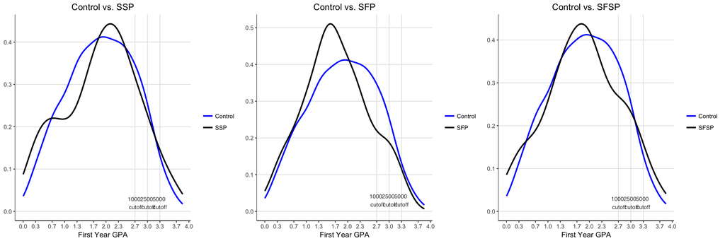

Figure 1a. Males’ Normalized First-year GPA

```r
#Aligned Results
figure <- egg::ggarrange(male.cont.vs.ssp, male.cont.vs.sfp, male.cont.vs.sfsp, nrow = 1)
```

**Figure 1b. Females’ Normalized First-Year GPA**

```r
############ Figure 1b. Females' Normalized First-Year GPA ############
#Control vs. SSP
femaleGPA.cont <- subset(dat.noshow, control == 1 & sex == "F" & GPA_year1 >= 0 ,
                       select=c(GPA_year1))
femaleGPA.ssp <- subset(dat.noshow, ssp == 1 & sex == "F" & GPA_year1 >= 0,
                      select=c(GPA_year1))

female.cont.vs.ssp <- ggplot() +
  scale_x_continuous(breaks=c(0, 0.3, 0.7, 1, 1.3, 1.7, 2, 2.3, 2.7, 3, 3.3, 3.7, 4)) +
  geom_vline(xintercept = 2.7,  color = "grey90") +
  geom_text(aes(x = 2.7, label = "1000 \n cutoff", y = 0.04),
            family = 'sans', angle=0, color = 'black', size = 3, alpha = 4/5) +
  geom_vline(xintercept = 3,  color = "grey90") +
  geom_text(aes(x = 3, label = "2500 \n cutoff", y = 0.04),
            family = 'sans', angle=0,  color = "black", size = 3, alpha = 4/5 ) +
  geom_vline(xintercept = 3.3,  color = "grey90") +
  geom_text(aes(x = 3.3, label = "5000 \n cutoff ", y = 0.04),
            family = 'sans', angle=0,  color = "black", size = 3, alpha = 4/5 ) +
  geom_hline(yintercept = c(0, 0.2, 0.4, 0.6),  color = "grey90") +
  stat_density(data = femaleGPA.cont, aes(x=GPA_year1, color="Control"), geom="line", position="identity",
               kernel = "gaussian", size = 1) +
  stat_density(data = femaleGPA.ssp, aes(x=GPA_year1, color="SSP"), geom="line", position="identity",
               kernel = "gaussian", size = 1) +
  xlab("First Year GPA") +
  scale_colour_manual(values = c("blue","black"),labels=c("Control","SSP")) +
  ggtitle("Control vs. SSP") +
  theme_bw() +
  guides(color=guide_legend(""))+
  theme(axis.title.y=element_blank(),
        panel.border = element_blank(), panel.grid.major = element_blank(),
        panel.grid.minor = element_blank(), axis.line = element_line(color = "black")) +
  theme(plot.title = element_text(hjust = 0.5))
```

```r
#Control vs. SFP
femaleGPA.sfp <- subset(dat.noshow, sfp == 1 & sex == "F" & GPA_year1 >= 0,
                      select=c(GPA_year1))

female.cont.vs.sfp <- ggplot() +
  scale_x_continuous(breaks=c(0, 0.3, 0.7, 1, 1.3, 1.7, 2, 2.3, 2.7, 3, 3.3, 3.7, 4)) +
  geom_vline(xintercept = 2.7,  color = "grey90") +
  geom_text(aes(x = 2.7, label = "1000 \n cutoff", y = 0.02),
            family = 'sans', angle=0, color = 'black', size = 3, alpha = 4/5) +
  geom_vline(xintercept = 3,  color = "grey90") +
  geom_text(aes(x = 3, label = "2500 \n cutoff", y = 0.02),
            family = 'sans', angle=0,  color = "black", size = 3, alpha = 4/5 ) +
  geom_vline(xintercept = 3.3,  color = "grey90") +
  geom_text(aes(x = 3.3, label = "5000 \n cutoff ", y = 0.02),
            family = 'sans', angle=0,  color = "black", size = 3, alpha = 4/5 ) +
  geom_hline(yintercept = c(0, 0.1, 0.2, 0.3, 0.4),  color = "grey90") +
  stat_density(data = femaleGPA.cont, aes(x=GPA_year1, color="Control"), geom="line", position="identity",
               kernel = "gaussian", size = 1) +
  stat_density(data = femaleGPA.sfp, aes(x=GPA_year1, color="SFP"), geom="line", position="identity",
               kernel = "gaussian", size = 1) +
  xlab("First Year GPA") +
  scale_colour_manual(values = c("blue","black"),labels=c("Control","SFP")) +
  ggtitle("Control vs. SFP") +
  theme_bw() +
  guides(color=guide_legend(""))+
  theme(axis.title.y=element_blank(),
        panel.border = element_blank(), panel.grid.major = element_blank(),
        panel.grid.minor = element_blank(), axis.line = element_line(color = "black")) +
  theme(plot.title = element_text(hjust = 0.5))
```

```r
#Control vs. SFSP
femaleGPA.sfsp <- subset(dat.noshow, sfsp == 1 & sex == "F" & GPA_year1 >= 0,
                       select=c(GPA_year1))

female.cont.vs.sfsp <- ggplot() +
  scale_x_continuous(breaks=c(0, 0.3, 0.7, 1, 1.3, 1.7, 2, 2.3, 2.7, 3, 3.3, 3.7, 4)) +
  geom_vline(xintercept = 2.7,  color = "grey90") +
  geom_text(aes(x = 2.7, label = "1000 \n cutoff", y = 0.03),
            family = 'sans', angle=0, color = 'black', size = 3, alpha = 4/5) +
  geom_vline(xintercept = 3,  color = "grey90") +
  geom_text(aes(x = 3, label = "2500 \n cutoff", y = 0.03),
            family = 'sans', angle=0,  color = "black", size = 3, alpha = 4/5 ) +
  geom_vline(xintercept = 3.3,  color = "grey90") +
  geom_text(aes(x = 3.3, label = "5000 \n cutoff ", y = 0.03),
            family = 'sans', angle=0,  color = "black", size = 3, alpha = 4/5 ) +
  geom_hline(yintercept = c(0, 0.1, 0.2, 0.3, 0.4, 0.5),  color = "grey90") +
  stat_density(data = femaleGPA.cont, aes(x=GPA_year1, color="Control"), geom="line", position="identity",
               kernel = "gaussian", size = 1) +
  stat_density(data = femaleGPA.sfsp, aes(x=GPA_year1, color="SFSP"), geom="line", position="identity",
               kernel = "gaussian", size = 1) +
  xlab("First Year GPA") +
  scale_colour_manual(values = c("blue","black"),labels=c("Control","SFSP")) +
  ggtitle("Control vs. SFSP") +
  theme_bw() +
  guides(color=guide_legend(""))+
  theme(axis.title.y=element_blank(),
        panel.border = element_blank(), panel.grid.major = element_blank(),
        panel.grid.minor = element_blank(), axis.line = element_line(color = "black")) +
  theme(plot.title = element_text(hjust = 0.5))
```

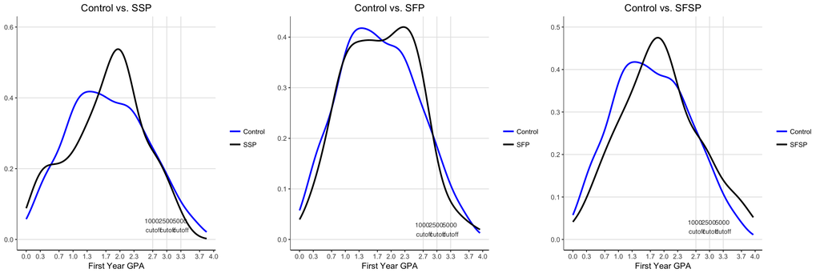

Figure 1b. Females’ Normalized First-year GPA

```r
#Aligned Results
figure <- egg::ggarrange(female.cont.vs.ssp, female.cont.vs.sfp, female.cont.vs.sfsp, nrow = 1)
```

**Robustness Check**

```r
############  Robustness Check (Different choices of controls) ############
rm(list = ls())
dat.STAR <- read_dta("STAR_public_use.dta")

#Control group mean and standard deviations
dat.STAR.ms <- dat.STAR[ ,c("sex","noshow","control","grade_20059_fall", "GPA_year1")]
dat.noshow.ms <- subset(dat.STAR.ms, noshow == 0)
dat.male.ms <- subset(dat.noshow.ms, sex == "M")
dat.female.ms <- subset(dat.noshow.ms, sex == "F")

dat.noshow.ms %>%
  na.omit(dat.noshow.ms) %>%
  group_by(control) %>%
  summarise(mean.grade_20059_fall = mean(grade_20059_fall),
            sd.grade_20059_fall = sd(grade_20059_fall),
            mean.GPA_year1 = mean(GPA_year1),
            sd.GPA_year1 = sd(GPA_year1))
```

```
## # A tibble: 2 x 5
##   control mean.grade_20059_fall sd.grade_20059_fall mean.GPA_year1
##     <dbl>                 <dbl>               <dbl>          <dbl>
## 1       0              65.50186            11.27924       1.858813
## 2       1              64.12824            11.77817       1.797449
## # ... with 1 more variables: sd.GPA_year1 <dbl>
```

```r
dat.male.ms %>%
  na.omit(dat.male.ms) %>%
  group_by(control) %>%
  summarise(mean.grade_20059_fall = mean(grade_20059_fall),
            sd.grade_20059_fall = sd(grade_20059_fall),
            mean.GPA_year1 = mean(GPA_year1),
            sd.GPA_year1 = sd(GPA_year1))
```

```
## # A tibble: 2 x 5
##   control mean.grade_20059_fall sd.grade_20059_fall mean.GPA_year1
##     <dbl>                 <dbl>               <dbl>          <dbl>
## 1       0              65.56808            11.64924       1.844911
## 2       1              65.73246            11.17780       1.885014
## # ... with 1 more variables: sd.GPA_year1 <dbl>
```

```r
dat.female.ms %>%
  na.omit(dat.female.ms) %>%
  group_by(control) %>%
  summarise(mean.grade_20059_fall = mean(grade_20059_fall),
            sd.grade_20059_fall = sd(grade_20059_fall),
            mean.GPA_year1 = mean(GPA_year1),
            sd.GPA_year1 = sd(GPA_year1))
```

```
## # A tibble: 2 x 5
##   control mean.grade_20059_fall sd.grade_20059_fall mean.GPA_year1
##     <dbl>                 <dbl>               <dbl>          <dbl>
## 1       0              65.45476            11.02707       1.868698
## 2       1              62.90647            12.08503       1.730759
## # ... with 1 more variables: sd.GPA_year1 <dbl>
```

```r
#Only do GPA for FALL grade sample
dat.STAR$GPA_year1[dat.STAR$grade_20059_fall =='.'] = '.'

#Only do FALL grade for GPA sample
dat.STAR$grade_20059_fall[dat.STAR$GPA_year1 =='.'] = '.'

#Converting multiple variables to factor
cols <- c("mtongue", "hsgroup", "numcourses_nov1", "lastmin", "mom_edn", "dad_edn")
dat.STAR[,cols] <- lapply(dat.STAR[,cols] , factor)

#Creating three subsets
dat.noshow <- subset(dat.STAR, noshow == 0)
dat.male <- subset(dat.noshow, sex == "M")
dat.female <- subset(dat.noshow, sex == "F")
list_data <- list("dat.noshow" = dat.noshow, "dat.male" = dat.male,
                  "dat.female" = dat.female)

#Relevant set of dependent variables
dep.var <-  c("grade_20059_fall", "GPA_year1")

#Panel A. All Students with Fall Grades
for (i in 1:length(dep.var)) {
  assign(paste("model.all.no", i, sep = ""),
         (lm(as.formula(paste(dep.var[[i]], "~ ssp + sfp + sfsp")), data = dat.noshow)))
}

for (i in 1:length(dep.var)) {
  assign(paste("model.all.basic", i, sep = ""),
         (lm(as.formula(paste(dep.var[[i]], "~ ssp + sfp + sfsp + mtongue + hsgroup + numcourses_nov1")), data = dat.noshow)))
}

for (i in 1:length(dep.var)) {
  assign(paste("model.all.cont", i, sep = ""),
         (lm(as.formula(paste(dep.var[[i]], "~ ssp + sfp + sfsp + mtongue + hsgroup + numcourses_nov1 +
                              lastmin + mom_edn +dad_edn")), data = dat.noshow)))
}
```

**Treatment Effect on Fall Grade and First-year Grade(Fall grades sample): Panel A. All Students with Fall Grades**

|  | *Dependent variable:* |  |  |  |  |  |
| --- | --- | --- | --- | --- | --- | --- |
|  | No Controls | Basic | All | No Controls | Basic | All |
|  | (1) | (2) | (3) | (4) | (5) | (6) |
| SSP | 0.253 | 0.065 | 0.258 | -0.006 | -0.013 | 0.011 |
|  | (0.964) | (0.934) | (0.966) | (0.067) | (0.061) | (0.064) |
| SFP | 1.988** | 1.645* | 1.638* | -0.012 | -0.037 | -0.044 |
|  | (0.859) | (0.845) | (0.876) | (0.062) | (0.058) | (0.061) |
| SFSP | 2.261** | 2.159** | 3.034*** | 0.072 | 0.081 | 0.166* |
|  | (1.069) | (1.053) | (1.101) | (0.086) | (0.082) | (0.086) |
| Constant | 63.843*** | 60.401*** | 60.149*** | 1.785*** | 1.348*** | 1.235*** |
|  | (0.414) | (3.079) | (3.606) | (0.030) | (0.280) | (0.338) |
| Observations | 1,398 | 1,398 | 1,274 | 1,533 | 1,533 | 1,399 |
| *Note:* | p<0.1; p<0.05; p<0.01 |  |  |  |  |  |
|  | The table reports regression estimates of treatment effects on Fall grades and First-year grades as the dependent variable using the different set of controls. Robust standard errors are reported in p… |  |  |  |  |  |

```r
#Panel B: Males
for (i in 1:length(dep.var)) {
  assign(paste("model.male.no", i, sep = ""),
         (lm(as.formula(paste(dep.var[[i]], "~ ssp + sfp + sfsp")), data = dat.male)))
}

for (i in 1:length(dep.var)) {
  assign(paste("model.male.basic", i, sep = ""),
         (lm(as.formula(paste(dep.var[[i]], "~ ssp + sfp + sfsp + mtongue + hsgroup + numcourses_nov1")), data = dat.male)))
}

for (i in 1:length(dep.var)) {
  assign(paste("model.male.cont", i, sep = ""),
         (lm(as.formula(paste(dep.var[[i]], "~ ssp + sfp + sfsp + mtongue + hsgroup + numcourses_nov1 +
                              lastmin + mom_edn +dad_edn")), data = dat.male)))
}
```

**Treatment Effect on Fall Grade and First-year Grade(Fall grades sample): Panel B: Males**

|  | *Dependent variable:* |  |  |  |  |  |
| --- | --- | --- | --- | --- | --- | --- |
|  | No Controls | Basic | All | No Controls | Basic | All |
|  | (1) | (2) | (3) | (4) | (5) | (6) |
| SSP | -0.431 | -0.536 | -0.019 | 0.005 | -0.014 | 0.017 |
|  | (1.512) | (1.484) | (1.480) | (0.107) | (0.098) | (0.102) |
| SFP | 0.792 | 0.332 | 0.567 | -0.148 | -0.161* | -0.144 |
|  | (1.286) | (1.263) | (1.265) | (0.096) | (0.093) | (0.098) |
| SFSP | -0.221 | -0.912 | 0.211 | -0.031 | -0.085 | 0.016 |
|  | (1.771) | (1.766) | (1.963) | (0.133) | (0.128) | (0.146) |
| Constant | 65.174*** | 60.567*** | 69.113*** | 1.851*** | 1.311*** | 1.713*** |
|  | (0.620) | (3.725) | (4.549) | (0.046) | (0.293) | (0.378) |
| Observations | 602 | 602 | 539 | 643 | 643 | 577 |
| *Note:* | p<0.1; p<0.05; p<0.01 |  |  |  |  |  |
|  | The table reports regression estimates of treatment effects on Fall grades and First-year grades as the dependent variable using the different set of controls. Robust standard errors are reported in p… |  |  |  |  |  |

```r
#Panel C: Females
for (i in 1:length(dep.var)) {
  assign(paste("model.female.no", i, sep = ""),
         (lm(as.formula(paste(dep.var[[i]], "~ ssp + sfp + sfsp")), data = dat.female)))
}

for (i in 1:length(dep.var)) {
  assign(paste("model.female.basic", i, sep = ""),
         (lm(as.formula(paste(dep.var[[i]], "~ ssp + sfp + sfsp + mtongue + hsgroup + numcourses_nov1")), data = dat.female)))
}

for (i in 1:length(dep.var)) {
  assign(paste("model.female.cont", i, sep = ""),
         (lm(as.formula(paste(dep.var[[i]], "~ ssp + sfp + sfsp + mtongue + hsgroup + numcourses_nov1 +
                              lastmin + mom_edn +dad_edn")), data = dat.female)))
}
```

**Treatment Effect on Fall Grade and First-year Grade(Fall grades sample): Panel C. Females**

|  | *Dependent variable:* |  |  |  |  |  |
| --- | --- | --- | --- | --- | --- | --- |
|  | No Controls | Basic | All | No Controls | Basic | All |
|  | (1) | (2) | (3) | (4) | (5) | (6) |
| SSP | 0.754 | 0.621 | 0.618 | -0.016 | -0.011 | 0.002 |
|  | (0.964) | (0.934) | (0.966) | (0.067) | (0.061) | (0.064) |
| SFP | 2.933*** | 2.629*** | 2.291*** | 0.081 | 0.051 | 0.038 |
|  | (0.859) | (0.845) | (0.876) | (0.062) | (0.058) | (0.061) |
| SFSP | 4.168*** | 4.291*** | 4.343*** | 0.148* | 0.197** | 0.244*** |
|  | (1.069) | (1.053) | (1.101) | (0.086) | (0.082) | (0.086) |
| Constant | 62.812*** | 62.709*** | 59.003*** | 1.736*** | 1.733*** | 1.546*** |
|  | (0.414) | (3.079) | (3.606) | (0.030) | (0.280) | (0.338) |
| Observations | 796 | 796 | 735 | 890 | 890 | 822 |
| *Note:* | p<0.1; p<0.05; p<0.01 |  |  |  |  |  |
|  | The table reports regression estimates of treatment effects on Fall grades and First-year grades as the dependent variable using the different set of controls. Robust standard errors are reported in p… |  |  |  |  |  |

```r
############ Robustness Check(Different size of the group) ############
rm(list = ls())
dat.STAR <- read_dta("STAR_public_use.dta")

#Converting multiple variables to factor
cols <- c("mtongue", "hsgroup", "numcourses_nov1", "lastmin", "mom_edn", "dad_edn")
dat.STAR[,cols] <- lapply(dat.STAR[,cols] , factor)

#Creating subset
dat.noshow <- subset(dat.STAR, noshow == 0 & compsurv == 1)

#Control group mean and standard deviations
dat.noshow.ms <- dat.noshow[ ,c("sex", "control","GPA_year1", "GPA_year2", "prob_year1", "prob_year2",
                                "goodstanding_year1", "goodstanding_year2", "credits_earned1","credits_earned2")]
dat.male.ms <- subset(dat.noshow.ms, sex == "M")
dat.female.ms <- subset(dat.noshow.ms, sex == "F")

ddply(dat.noshow.ms, .(control), colwise(mean), na.rm=TRUE)
```

```
##   control sex GPA_year1 GPA_year2 prob_year1 prob_year2 goodstanding_year1
## 1       0  NA  1.815882  2.077054  0.1941924  0.2468240          0.4928571
## 2       1  NA  1.793906  2.040013  0.2214533  0.2468281          0.4638347
##   goodstanding_year2 credits_earned1 credits_earned2
## 1          0.6357143        2.382486        2.476860
## 2          0.6337543        2.364055        2.492224
```

```r
ddply(dat.noshow.ms, .(control), colwise(sd), na.rm=TRUE)
```

```
##   control sex GPA_year1 GPA_year2 prob_year1 prob_year2 goodstanding_year1
## 1       0  NA 0.8820061 0.9180849  0.3959371  0.4315552          0.5003960
## 2       1  NA 0.9152375 0.8838554  0.4154646  0.4314147          0.4989769
##   goodstanding_year2 credits_earned1 credits_earned2
## 1          0.4816595       0.9627881        1.464748
## 2          0.4820545       0.9854527        1.501301
```

```r
ddply(dat.male.ms, .(control), colwise(mean), na.rm=TRUE)
```

```
##   control sex GPA_year1 GPA_year2 prob_year1 prob_year2 goodstanding_year1
## 1       0  NA  1.807149   1.97335  0.1725664  0.2654867          0.4366812
## 2       1  NA  1.871208   2.08434  0.1593407  0.2527473          0.4849315
##   goodstanding_year2 credits_earned1 credits_earned2
## 1          0.6113537        2.295354        2.387168
## 2          0.6438356        2.454795        2.469178
```

```r
ddply(dat.male.ms, .(control), colwise(sd), na.rm=TRUE)
```

```
##   control sex GPA_year1 GPA_year2 prob_year1 prob_year2 goodstanding_year1
## 1       0  NA 0.9004729 0.9777493  0.3787107  0.4425723          0.4970610
## 2       1  NA 0.9039157 0.9012897  0.3664972  0.4351854          0.5004589
##   goodstanding_year2 credits_earned1 credits_earned2
## 1          0.4885104        0.943628        1.456019
## 2          0.4795219        1.067604        1.523593
```

```r
ddply(dat.female.ms, .(control), colwise(mean), na.rm=TRUE)
```

```
##   control sex GPA_year1 GPA_year2 prob_year1 prob_year2 goodstanding_year1
## 1       0  NA  1.821858  2.152509  0.2092308  0.2338462          0.5317221
## 2       1  NA  1.738758  2.008050  0.2664016  0.2425447          0.4486166
##   goodstanding_year2 credits_earned1 credits_earned2
## 1          0.6525680        2.443077        2.539231
## 2          0.6264822        2.298211        2.508946
```

```r
ddply(dat.female.ms, .(control), colwise(sd), na.rm=TRUE)
```

```
##   control sex GPA_year1 GPA_year2 prob_year1 prob_year2 goodstanding_year1
## 1       0  NA 0.8705015 0.8661144  0.4073867  0.4239282          0.4997482
## 2       1  NA 0.9201655 0.8706948  0.4425168  0.4290487          0.4978449
##   goodstanding_year2 credits_earned1 credits_earned2
## 1          0.4768753       0.9727331        1.469796
## 2          0.4842165       0.9167470        1.486215
```

```r
#ADDITIONAL SAMPLE SELECTION
dat.noshow$prob_year1[dat.noshow$prob_year1 =='.'] = '.'
dat.noshow$prob_year2[dat.noshow$prob_year1 =='.'] = '.'
dat.noshow$goodstanding_year1[dat.noshow$prob_year1 =='.'] = '.'
dat.noshow$goodstanding_year2[dat.noshow$prob_year1 =='.'] = '.'
dat.noshow$credits_earned1[dat.noshow$prob_year1 =='.'] = '.'
dat.noshow$credits_earned2[dat.noshow$prob_year1 =='.'] = '.'

#Sample in all control spec
dat.noshow <- subset(dat.noshow, sex!="" & mtongue!="" & hsgroup!="." &
                       numcourses_nov1!="." & lastmin!="." & mom_edn!="." & dad_edn!=".")

#Creating subsets and data list
dat.male <- subset(dat.noshow, sex == "M")
dat.female <- subset(dat.noshow, sex == "F")
list_data <- list("dat.noshow" = dat.noshow, "dat.male" = dat.male,
                  "dat.female" = dat.female)
#Panel A. GPA
model.GPA.one1 <- lm(GPA_year1 ~ ssp + sfp + sfsp + sex + mtongue + hsgroup + numcourses_nov1 +
     lastmin + mom_edn + dad_edn + age + chooseUTM + finish4 + work1, data = dat.noshow)

for (i in 2:3) {
  assign(paste("model.GPA.one", i, sep = ""),
         (lm(GPA_year1 ~ ssp + sfp + sfsp + mtongue + hsgroup + numcourses_nov1 +
             lastmin + mom_edn + dad_edn + age + chooseUTM + finish4 + work1, data = list_data[[i]])))
}

model.GPA.two1 <- lm(GPA_year2 ~ ssp + sfp + sfsp + sex + mtongue + hsgroup + numcourses_nov1 +
                       lastmin + mom_edn + dad_edn + age + chooseUTM + finish4 + work1, data = dat.noshow)

for (i in 2:3) {
  assign(paste("model.GPA.two", i, sep = ""),
         (lm(GPA_year2 ~ ssp +  sfp + sfsp  + mtongue + hsgroup + numcourses_nov1 +
             lastmin + mom_edn + dad_edn + age + chooseUTM + finish4 + work1, data = list_data[[i]])))
}
```

**Treatment Effects on First and Second Year Outcomes (Robustness Check): Panel A. GPA**

|  | Dependent Variable: GPA |  |  |  |  |  |
| --- | --- | --- | --- | --- | --- | --- |
|  | All | Men | Women | All | Men | Women |
|  | (1) | (2) | (3) | (4) | (5) | (6) |
| SSP | 0.003 | 0.014 | -0.007 | 0.051 | -0.009 | 0.091 |
|  | (0.063) | (0.101) | (0.081) | (0.074) | (0.120) | (0.092) |
| SFP | -0.055 | -0.153 | 0.019 | -0.032 | -0.094 | 0.023 |
|  | (0.062) | (0.100) | (0.081) | (0.067) | (0.111) | (0.087) |
| SFSP | 0.169** | 0.035 | 0.226** | 0.077 | -0.157 | 0.275*** |
|  | (0.086) | (0.145) | (0.112) | (0.091) | (0.161) | (0.106) |
| Constant | 3.446*** | 3.643*** | 3.991*** | 4.576*** | 4.387*** | 4.666*** |
|  | (0.824) | (1.184) | (1.026) | (0.915) | (1.294) | (1.155) |
| Observations | 1,396 | 577 | 819 | 1,238 | 521 | 717 |
| *Note:* | p<0.1; p<0.05; p<0.01 |  |  |  |  |  |
|  | The table reports regression estimates of treatment effects computed using the full set of controls plus age, at first choice school, plans to work while in school and intends to finish in 4 years. Ro… |  |  |  |  |  |

```r
#Panel B. On Probation/Withdrew
model.prob.one1 <- lm(prob_year1 ~ ssp + sfp + sfsp + sex + mtongue + hsgroup + numcourses_nov1 +
                       lastmin + mom_edn + dad_edn + age + chooseUTM + finish4 + work1, data = dat.noshow)
for (i in 2:3) {
  assign(paste("model.prob.one", i, sep = ""),
         (lm(prob_year1 ~ ssp + sfp + sfsp + mtongue + hsgroup + numcourses_nov1 +
               lastmin + mom_edn + dad_edn + age + chooseUTM + finish4 + work1, data = list_data[[i]])))
}

model.prob.two1 <- lm(prob_year2 ~ ssp + sfp + sfsp + sex + mtongue + hsgroup + numcourses_nov1 +
                        lastmin + mom_edn + dad_edn + age + chooseUTM + finish4 + work1, data = dat.noshow)
for (i in 2:3) {
  assign(paste("model.prob.two", i, sep = ""),
         (lm(prob_year2 ~ ssp +  sfp + sfsp  + mtongue + hsgroup + numcourses_nov1 +
               lastmin + mom_edn + dad_edn + age + chooseUTM + finish4 + work1, data = list_data[[i]])))
}
```

**Treatment Effects on First and Second Year Outcomes (Robustness Check): Panel B. On Probation/withdrew**

|  | Dependent Variable: On Probation/withdrew |  |  |  |  |  |
| --- | --- | --- | --- | --- | --- | --- |
|  | All | Men | Women | All | Men | Women |
|  | (1) | (2) | (3) | (4) | (5) | (6) |
| SSP | -0.013 | 0.018 | -0.036 | 0.024 | 0.008 | 0.050 |
|  | (0.031) | (0.045) | (0.043) | (0.033) | (0.050) | (0.044) |
| SFP | -0.022 | 0.010 | -0.055 | 0.013 | 0.013 | 0.003 |
|  | (0.031) | (0.050) | (0.041) | (0.032) | (0.053) | (0.042) |
| SFSP | -0.063* | -0.019 | -0.094* | -0.055 | 0.002 | -0.092** |
|  | (0.036) | (0.055) | (0.051) | (0.038) | (0.067) | (0.046) |
| Constant | 0.523 | 0.209 | 0.543 | -1.212*** | -1.361** | -1.377** |
|  | (0.339) | (0.522) | (0.451) | (0.432) | (0.595) | (0.557) |
| Observations | 1,415 | 590 | 825 | 1,415 | 590 | 825 |
| *Note:* | p<0.1; p<0.05; p<0.01 |  |  |  |  |  |
|  | The probation variable indicates academic probation in the first year and probation or withdrawal in the second year. |  |  |  |  |  |

```r
#Panel C. Good Standing
model.gds.one1 <- lm(goodstanding_year1 ~ ssp + sfp + sfsp + sex + mtongue + hsgroup + numcourses_nov1 +
                        lastmin + mom_edn + dad_edn + age + chooseUTM + finish4 + work1, data = dat.noshow)
for (i in 2:3) {
  assign(paste("model.gds.one", i, sep = ""),
         (lm(goodstanding_year1 ~ ssp + sfp + sfsp + mtongue + hsgroup + numcourses_nov1 +
               lastmin + mom_edn + dad_edn + age + chooseUTM + finish4 + work1, data = list_data[[i]])))
}

model.gds.two1 <- lm(goodstanding_year2 ~ ssp + sfp + sfsp + sex + mtongue + hsgroup + numcourses_nov1 +
                        lastmin + mom_edn + dad_edn + age + chooseUTM + finish4 + work1, data = dat.noshow)
for (i in 2:3) {
  assign(paste("model.gds.two", i, sep = ""),
         (lm(goodstanding_year2 ~ ssp +  sfp + sfsp  + mtongue + hsgroup + numcourses_nov1 +
               lastmin + mom_edn + dad_edn + age + chooseUTM + finish4 + work1, data = list_data[[i]])))
}
```

**Treatment Effects on First and Second Year Outcomes (Robustness Check): Panel C. Good standing**

|  | Dependent Variable: Good standing |  |  |  |  |  |
| --- | --- | --- | --- | --- | --- | --- |
|  | All | Men | Women | All | Men | Women |
|  | (1) | (2) | (3) | (4) | (5) | (6) |
| SSP | 0.036 | -0.066 | 0.102** | -0.035 | -0.038 | -0.041 |
|  | (0.035) | (0.055) | (0.046) | (0.036) | (0.056) | (0.048) |
| SFP | 0.012 | -0.050 | 0.062 | 0.002 | -0.008 | 0.021 |
|  | (0.035) | (0.055) | (0.047) | (0.034) | (0.058) | (0.044) |
| SFSP | 0.049 | -0.014 | 0.080 | 0.060 | 0.019 | 0.088 |
|  | (0.048) | (0.077) | (0.064) | (0.043) | (0.071) | (0.055) |
| Constant | 1.033*** | 1.485*** | 0.985* | 1.689*** | 1.751*** | 2.449*** |
|  | (0.393) | (0.571) | (0.552) | (0.476) | (0.625) | (0.579) |
| Observations | 1,428 | 594 | 834 | 1,428 | 594 | 834 |
| *Note:* | p<0.1; p<0.05; p<0.01 |  |  |  |  |  |
|  | The credits earned and good standing variables are zero in the second year for those who withdrew. |  |  |  |  |  |

```r
#Panel D. Credits Earned
model.cred.one1 <- lm(credits_earned1 ~ ssp + sfp + sfsp + sex + mtongue + hsgroup + numcourses_nov1 +
                       lastmin + mom_edn + dad_edn + age + chooseUTM + finish4 + work1, data = dat.noshow)
for (i in 2:3) {
  assign(paste("model.cred.one", i, sep = ""),
         (lm(credits_earned1 ~ ssp + sfp + sfsp + mtongue + hsgroup + numcourses_nov1 +
               lastmin + mom_edn + dad_edn + age + chooseUTM + finish4 + work1, data = list_data[[i]])))
}

model.cred.two1 <- lm(credits_earned2 ~ ssp + sfp + sfsp + sex + mtongue + hsgroup + numcourses_nov1 +
                       lastmin + mom_edn + dad_edn + age + chooseUTM + finish4 + work1, data = dat.noshow)
for (i in 2:3) {
  assign(paste("model.cred.two", i, sep = ""),
         (lm(credits_earned2 ~ ssp +  sfp + sfsp + mtongue + hsgroup + numcourses_nov1 +
               lastmin + mom_edn + dad_edn + age + chooseUTM + finish4 + work1, data = list_data[[i]])))
}
```

**Treatment Effects on First and Second Year Outcomes (Robustness Check): Panel D. Credits earned**

|  | Dependent Variable: Credits earned |  |  |  |  |  |
| --- | --- | --- | --- | --- | --- | --- |
|  | All | Men | Women | All | Men | Women |
|  | (1) | (2) | (3) | (4) | (5) | (6) |
| SSP | 0.039 | -0.088 | 0.122 | -0.107 | -0.186 | -0.064 |
|  | (0.072) | (0.107) | (0.100) | (0.115) | (0.175) | (0.153) |
| SFP | -0.031 | -0.175* | 0.068 | 0.002 | 0.138 | -0.047 |
|  | (0.064) | (0.103) | (0.082) | (0.107) | (0.178) | (0.138) |
| SFSP | 0.114 | -0.141 | 0.275** | 0.090 | -0.190 | 0.280 |
|  | (0.088) | (0.152) | (0.110) | (0.129) | (0.201) | (0.173) |
| Constant | 4.430*** | 5.062*** | 5.174*** | 6.941*** | 7.919*** | 6.895*** |
|  | (0.850) | (1.286) | (1.003) | (1.412) | (1.928) | (1.902) |
| Observations | 1,416 | 591 | 825 | 1,416 | 591 | 825 |
| *Note:* | p<0.1; p<0.05; p<0.01 |  |  |  |  |  |
|  | The credits earned and good standing variables are zero in the second year for those who withdrew. |  |  |  |  |  |